# Knowledge and Perception of Zoonotic Diseases among Healthcare Professionals, Ghana

Association or Relationships analysis

Laurens

01 May, 2025

# Data overview

```
## # A tibble: 152 × 121
##      age sex    profession     years_experience location has_animal animal_types
##    <dbl> <fct>  <fct>                     <dbl> <chr>    <chr>      <chr>
##  1    35 Female Medical Doctor                6 Tolon    Yes        Cats, Dog, …
##  2    30 Male   Nurse                         5 Tolon    Yes        Dog
##  3    31 Male   Nurse                         4 Tolon    No         None
##  4    30 Female Biomedical Sc…                2 Tolon    Yes        Cat
##  5    36 Female Nurse                         2 Tolon    No         None
##  6    30 Female Nurse                         3 Tolon    Yes        Cat, Dog
##  7    28 Female Nurse                         3 Tolon    No         None
##  8    31 Female Nurse                         3 Tolon    No         None
##  9    26 Female Nurse                         1 Tolon    No         None
## 10    29 Male   Nurse                         2 Tolon    No         None
## # ℹ 142 more rows
## # ℹ 114 more variables: has_cat <chr>, has_dog <chr>, has_goat <chr>,
## #   has_sheep <chr>, has_cattle <chr>, has_poultry <chr>,
## #   zoonosis_definition <chr>, zoonosis_classification <chr>,
## #   zoonosis_infectious <chr>, zoonosis_knowledge_total <dbl>,
## #   zoonosis_knowledge_cat <fct>, anthrax_prioritized <chr>,
## #   rabies_prioritized <chr>, avian_influenza_prioritized <chr>, …
```

[output not shown]

[output not shown]

Cronbach’s Alpha for Knowledge Scales

| Scale | N_Items | N_Respondents | Cronbach_Alpha |
| --- | --- | --- | --- |
| General Zoonosis Knowledge | 3 | 152 | 0.31 |
| Prioritized Zoonoses Knowledge | 9 | 152 | 0.75 |
| Anthrax Knowledge | 8 | 152 | 0.54 |
| Rabies Knowledge | 8 | 152 | 0.41 |
| Brucellosis Knowledge | 8 | 152 | 0.70 |
| Trypanosomiasis Knowledge | 8 | 152 | 0.53 |
| Tuberculosis Knowledge | 8 | 152 | 0.67 |
| One Health Knowledge | 14 | 152 | 0.80 |

[output not shown]

Overall Cronbach’s Alpha for Knowledge Items

| Scale | N_Items | N_Respondents | Cronbach_Alpha |
| --- | --- | --- | --- |
| Overall Knowledge (All Items) | 66 | 152 | 0.88 |

# Demographics

Distribution of Profession

| profession | n | Percentage (%) |
| --- | --- | --- |
| Biomedical Scientist | 8 | 5.26 |
| Medical Doctor | 4 | 2.63 |
| Nurse | 135 | 88.82 |
| Pharmacist | 5 | 3.29 |

Distribution of Gender

| sex | n | Percentage (%) |
| --- | --- | --- |
| Female | 87 | 57.24 |
| Male | 65 | 42.76 |

Distribution of location

| location | n | Percentage (%) |
| --- | --- | --- |
| Nyankpala | 31 | 20.39 |
| Tolon | 121 | 79.61 |

Distribution of Having Animal Status

| has_animal | n | Percentage (%) |
| --- | --- | --- |
| No | 61 | 40.13 |
| Yes | 91 | 59.87 |

Summary Statistics of Age

| Mean | Median | SD | Min | Max |
| --- | --- | --- | --- | --- |
| 31.09 | 30 | 4.46 | 24 | 51 |

Summary Statistics of Years Of Experience

| Mean | Median | SD | Min | Max |
| --- | --- | --- | --- | --- |
| 3.61 | 3 | 2.99 | 1 | 17 |

| **Variable** | **Biomedical Scientist** N = 8<sup>1</sup> | **Medical Doctor** N = 4<sup>1</sup> | **Nurse** N = 135<sup>1</sup> | **Pharmacist** N = 5<sup>1</sup> | **p-value**<sup>2</sup> |
| --- | --- | --- | --- | --- | --- |
| age | 34.9, (8.2) | 42.3, (8.0) | 30.4, (3.4) | 34.4, (4.9) | 0.004 |
| sex |  |  |  |  | 0.4 |
| Female | 3 (38%) | 1 (25%) | 80 (59%) | 3 (60%) |  |
| Male | 5 (63%) | 3 (75%) | 55 (41%) | 2 (40%) |  |
| years_experience | 6.0, (6.5) | 4.0, (2.4) | 3.3, (2.4) | 8.2, (4.9) | 0.12 |
| has_animal | 6 (75%) | 2 (50%) | 80 (59%) | 3 (60%) | 0.9 |
| location |  |  |  |  | 0.003 |
| Nyankpala | 4 (50%) | 3 (75%) | 22 (16%) | 2 (40%) |  |
| Tolon | 4 (50%) | 1 (25%) | 113 (84%) | 3 (60%) |  |

<sup>1</sup> Mean, (SD); n (%)  
<sup>2</sup> Kruskal-Wallis rank sum test; Fisher’s exact test

Age 20-29 30-40 and more

Professional group Nurse  
Other

Proffesional experince  
1-5  
6-10 and more

Pet at home No  
Yes

Location  
Tolon  
Nyankpala

Encountered any zoonose in praxis

Participated in workshop training on zoonosis or one health

Tought at school on zoonois

Tought at school on One health

- Observations
1. Demographic Characteristics

Sample Size and Professions: Total observations: 152 health professionals.

Professions: Nurse (135, 88.8%), Biomedical Scientist (8, 5.3%), Pharmacist (5, 3.3%), Medical Doctor (4, 2.6%). The dominance of Nurses limits statistical power for other groups.

Age: Mean age: 31.09 years ( demo_table show variation by profession).

demo_table: Significant differences in age across professions (p=0.004, Kruskal-Wallis):

Biomedical Scientist: 34.9 (SD 8.2)

Medical Doctor: 42.3 (SD 8.0)

Nurse: 30.4 (SD 3.4)

Pharmacist: 34.4 (SD 4.9)

Medical Doctors are older on average, while Nurses are younger.

Sex:

Overall: 87 Females (57.2%), 65 Males (42.8%).

demo_table: Sex distribution varies by profession (p=0.4, Fisher’s exact test, not significant):

Biomedical Scientist: 38% Female, 63% Male

Medical Doctor: 25% Female, 75% Male

Nurse: 59% Female, 41% Male

Pharmacist: 60% Female, 40% Male

Nurses and Pharmacists have a higher proportion of females compared to Medical Doctors and Biomedical Scientists.

Years of Experience:

Mean: 3.61 years (range: 1–17).

demo_table: No significant differences (p=0.12, Kruskal-Wallis):

Biomedical Scientist: 6.0 (SD 6.5)

Medical Doctor: 4.0 (SD 2.4)

Nurse: 3.3 (SD 2.4)

Pharmacist: 8.2 (SD 4.9)

Pharmacists have the highest average experience, but variability is high.

Location:

Two locations: Tolon (121, 79.6%), Nyankpala (31, 20.4%).

demo_table: Significant differences (p=0.003, Fisher’s exact test):

Biomedical Scientist: 50% Tolon, 50% Nyankpala

Medical Doctor: 25% Tolon, 75% Nyankpala

Nurse: 84% Tolon, 16% Nyankpala

Pharmacist: 60% Tolon, 40% Nyankpala

Nurses are predominantly in Tolon, while Medical Doctors are mostly in Nyankpala.

Animal Ownership:

91 (59.9%) own animals, 61 (40.1%) do not.

demo_table: No significant differences (p=0.9, Fisher’s exact test):

Biomedical Scientist: 75% Yes

Medical Doctor: 50% Yes

Nurse: 59% Yes

Pharmacist: 60% Yes

Animal types: Sheep (60), goats (52), dogs (39), cattle (30), cats (26), poultry (21). Many NAs in specific animal variables ( 126 NAs for has_cat).

2. General Knowledge of Zoonosis

Zoonosis Knowledge Total (zoonosis_knowledge_total, 0–3):

Mean: 1.53 (median: 1, range: 0–3), moderate knowledge.

Zoonosis Knowledge Category (zoonosis_knowledge_cat):

High general knowledge: 70 (46.1%)

Low general knowledge: 82 (53.9%)

Imbalanced, with slightly more low knowledge.

Components:

zoonosis_definition: 63 Correct (41.4%), 89 Incorrect (58.6%).

zoonosis_classification: 47 Correct (30.9%), 105 Incorrect (69.1%).

zoonosis_infectious: 122 Correct (80.3%), 30 Incorrect (19.7%).

Strongest knowledge in infectious nature, weakest in classification.

3. Knowledge of Prioritized Zoonoses in Ghana

Prioritized Zoonoses Knowledge Total (prioritized_zoonoses_knowledge_total, 0–9): Mean: 6.53 (median: 7, range: 0–9), relatively high knowledge.

Prioritized Zoonoses Knowledge Category (prioritized_zoonoses_knowledge_cat): High knowledge: 133 (87.5%)

Low knowledge: 19 (12.5%)

most respondents showing high knowledge.

Specific Diseases: Strong knowledge: Rabies (141 Correct, 92.8%), Anthrax (127, 83.6%), Ebola (118, 77.6%), TB (115, 75.7%), Trypanosomiasis (110, 72.4%), Yellow Fever (107, 70.4%).

Weaker knowledge: Lassa Fever (101, 66.4%), Dengue Fever (87, 57.2%), Avian Influenza (87, 57.2%).

Rabies and Anthrax are best understood, while Avian Influenza and Dengue Fever lag.

4. Knowledge of Five Selected Zoonoses (Anthrax, Rabies, Brucellosis, Trypanosomiasis, Tuberculosis)

Anthrax Knowledge:

anthrax_knowledge_total: Mean 3.02 (range: 0–8).

anthrax_knowledge_cat: 151 Inadequate (99.3%), 1 Adequate (0.7%)—nearly invariant.

Strong areas: Vaccination (92 Correct, 60.5%), causative agent (79, 52.0%), signs (63, 41.4%).

Weak areas: Diagnostic test (8 Correct, 5.3%), differential diagnosis (41, 27.0%).

Rabies Knowledge:

rabies_knowledge_total: Mean 4.02 (range: 0–8), highest among the five.

rabies_knowledge_cat: 150 Inadequate (98.7%), 2 Adequate (1.3%)—nearly invariant.

Strong areas: Vaccination (116 Correct, 76.3%), causative agent (114, 75.0%), transmission (89, 58.6%).

Weak areas: Diagnostic test (20 Correct, 13.2%), differential diagnosis (46, 30.3%).

Brucellosis Knowledge:

brucellosis_knowledge_total: Mean 2.06 (range: 0–7), lowest among the five.

brucellosis_knowledge_cat: 152 Inadequate (100%)—completely invariant.

Strong areas: Treatment drug (51 Correct, 33.6%), differential diagnosis (48, 31.6%).

Weak areas: Transmission (28 Correct, 18.4%), diagnostic sample (26, 17.1%), vaccination (29, 19.1%).

Trypanosomiasis Knowledge:

trypanosomiasis_knowledge_total: Mean 2.95 (range: 0–7).

trypanosomiasis_knowledge_cat: 152 Inadequate (100%)—completely invariant.

Strong areas: Transmission (100 Correct, 65.8%), diagnostic sample (61, 40.1%).

Weak areas: Treatment drug (40 Correct, 26.3%), signs (46, 30.3%), vaccination (42, 27.6%).

Tuberculosis Knowledge:

tb_knowledge_total: Mean 3.82 (range: 0–7).

tb_knowledge_cat: 152 Inadequate (100%)—completely invariant.

Strong areas: Diagnostic sample (106 Correct, 69.7%), treatment drug (85, 55.9%), transmission (85, 55.9%).

Weak areas: Differential diagnosis (30 Correct, 19.7%), diagnostic test (44, 28.9%).

Observation: Rabies knowledge is the strongest, while Brucellosis is the weakest.

5. Knowledge of One Health and Related Issues

One Health Knowledge Total (one_health_knowledge_total, 0–14):

Mean: 9.18 (median: 10, range: 0–14), indicating strong knowledge.

One Health Knowledge Category (one_health_knowledge_cat):

High knowledge: 120 (78.9%)

Low knowledge: 32 (21.1%)

most respondents showing high knowledge.

Components:

Strong areas: Food safety (116 Correct, 76.3%), zoonosis (113, 74.3%), biodiversity (107, 70.4%), antibiotic resistance (107, 70.4%), mental health (107, 70.4%), plant pests (106, 69.7%), climate change (106, 69.7%), animal welfare (105, 69.1%), non-communicable diseases (104, 68.4%).

Weaker areas: Animal husbandry (100, 65.8%), urbanization (95, 62.5%), deforestation (86, 56.6%), armed conflict (62, 40.8%), definition (82, 53.9%).

Food safety and zoonosis are best understood, while armed conflict and the One Health definition are least understood.

6. Experience with Zoonoses and One Health

Zoonosis Workshop (zoonosis_workshop): No: 141 (92.8%), Yes: 11 (7.2%).

Low participation, limiting analysis power.

Zoonosis Collaboration (zoonosis_collaboration): No: 143 (94.1%), Yes: 9 (5.9%).

All collaborations involve Rabies (collaborated_zoonotic_diseases: 143 None, 9 Rabies).

Zoonotic Disease Encounter (zoonotic_disease_encounter): No: 101 (66.4%), Yes: 51 (33.6%).

Encountered diseases (encountered_zoonotic_diseases_1): Rabies (41), Ebola (4), TB (3), Anthrax (2), Trypanosomiasis (1), None (101).

encountered_zoonotic_diseases_2: Mostly None (150), with 2 Rabies cases.

Rabies is the most encountered zoonotic disease.

Zoonosis Public Education (zoonosis_public_education): No: 138 (90.8%), Yes: 14 (9.2%).

Educated diseases (public_educated_zoonotic_diseases): None (138), Rabies (13), Ebola (1).

One Health Training (one_health_training): No: 120 (78.9%), Yes: 32 (21.1%).

Zoonosis Training (zoonosis_training): No: 98 (64.5%), Yes: 54 (35.5%).

Observation: Engagement in zoonosis-related activities (workshops, collaboration, education) is low, with Rabies dominating encounters and education efforts. Training in One Health and zoonosis is more common but still limited.

7. Binary Disease Indicators

Collaboration: collab_rabies: 9 Yes (5.9%), 143 No (94.1%).

Others (collab_anthrax, collab_brucellosis, collab_trypanosomiasis, collab_tuberculosis): All 0, unsuitable for analysis.

Encounters:

encounter_rabies: 43 Yes (28.3%), 109 No (71.7%).

encounter_anthrax: 2 Yes (1.3%), 150 No (98.7%).

encounter_tuberculosis: 3 Yes (2.0%), 149 No (98.0%).

encounter_trypanosomiasis: 1 Yes (0.7%), 151 No (99.3%).

encounter_brucellosis: All 0.

Public Education:

educate_rabies: 13 Yes (8.6%), 139 No (91.4%).

Others (educate_anthrax, educate_brucellosis, educate_trypanosomiasis, educate_tuberculosis): All 0.

Observation: Rabies dominates collaboration, encounters, and public education. Other diseases have extremely low prevalence, limiting their analysis.

- Summary

The dataset reveals a predominantly Nurse-based sample (88.8%) with moderate general zoonosis knowledge, strong knowledge of prioritized zoonoses (especially Rabies and Anthrax), and robust One Health knowledge (mean 9.18/14). Rabies dominates zoonotic disease encounters (28.3%), collaboration (5.9%), and public education (8.6%), while other diseases (e.g., Brucellosis, Anthrax) have negligible engagement. Knowledge of Brucellosis is the weakest among the five zoonoses, and individual disease knowledge categories are nearly invariant, necessitating numeric or composite scores for analysis. Low engagement in workshops (7.2%), collaboration (5.9%), and public education (9.2%) highlights gaps in zoonosis-related activities. The small sample sizes for Medical Doctors and Pharmacists, combined with imbalanced categorical variables and low-prevalence binary outcomes, pose challenges for detecting significant associations with profession. The significant differences in age and location by profession suggest potential confounders for the planned analyses.

# Relationships

- Profession vs General Knowledge of Zoonosis

  Profession vs Total Correct Scores in General Knowledge of Zoonosis items

  |  | 0 | 1 | 2 | 3 |
  | --- | --- | --- | --- | --- |
  | Biomedical Scientist | 0 | 5 | 2 | 1 |
  | Medical Doctor | 0 | 2 | 2 | 0 |
  | Nurse | 13 | 59 | 40 | 23 |
  | Pharmacist | 2 | 1 | 1 | 1 |

```
##              Df Sum Sq Mean Sq F value Pr(>F)
## profession    3   0.57  0.1896   0.239  0.869
## Residuals   148 117.33  0.7927
```

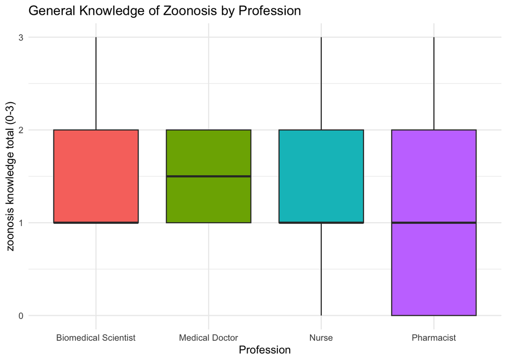

Profession vs Level of General Knowledge on Zoonosis

|  | Count high general knowledge | Count low general knowledge | Percentage (%) high general knowledge | Percentage (%) low general knowledge |
| --- | --- | --- | --- | --- |
| Biomedical Scientist | 3 | 5 | 37.50 | 62.50 |
| Medical Doctor | 2 | 2 | 50.00 | 50.00 |
| Nurse | 63 | 72 | 46.67 | 53.33 |
| Pharmacist | 2 | 3 | 40.00 | 60.00 |

Note:  
Chi-square test: X² = 0.35 , df = 3 , p-value = 0.949

```
##
##  Fisher's Exact Test for Count Data
##
## data:  prof_zoon_know
## p-value = 0.9651
## alternative hypothesis: two.sided
```

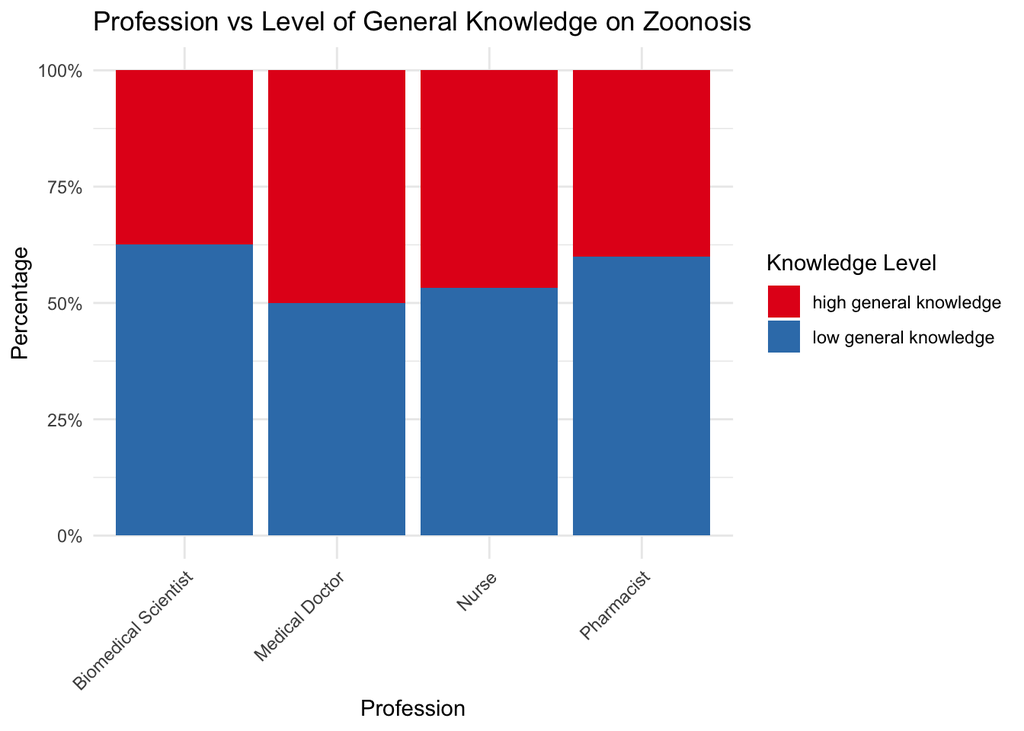

- Profession vs Knowledge of Prioritized Zoonoses

```
##
##  Fisher's Exact Test for Count Data
##
## data:  prof_kn_prior
## p-value = 0.7932
## alternative hypothesis: two.sided
```

Profession vs Knowledge of Prioritized Zoonoses

|  | Count high knowledge | Count low knowledge | Percentage (%) high knowledge | Percentage (%) low knowledge |
| --- | --- | --- | --- | --- |
| Biomedical Scientist | 7 | 1 | 87.50 | 12.50 |
| Medical Doctor | 4 | 0 | 100.00 | 0.00 |
| Nurse | 118 | 17 | 87.41 | 12.59 |
| Pharmacist | 4 | 1 | 80.00 | 20.00 |

Note:  
Fisher’s exact test: p-value = 0.793

Profession vs Knowledge of Prioritized Zoonoses items (Count)

|  | 0 | 1 | 2 | 3 | 4 | 5 | 6 | 7 | 8 | 9 |
| --- | --- | --- | --- | --- | --- | --- | --- | --- | --- | --- |
| Biomedical Scientist | 0 | 0 | 1 | 0 | 0 | 0 | 1 | 1 | 1 | 4 |
| Medical Doctor | 0 | 0 | 0 | 0 | 0 | 0 | 0 | 1 | 2 | 1 |
| Nurse | 6 | 1 | 2 | 1 | 7 | 20 | 32 | 14 | 19 | 33 |
| Pharmacist | 0 | 0 | 0 | 1 | 0 | 2 | 1 | 0 | 1 | 0 |

```
##              Df Sum Sq Mean Sq F value Pr(>F)
## profession    3   21.1   7.019   1.399  0.246
## Residuals   148  742.8   5.019
```

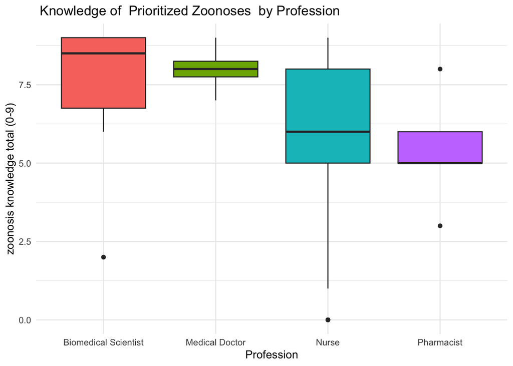

- Observations
1. Profession vs. General Knowledge of Zoonosis (zoonosis_knowledge_total)

Cross-tabulation (Counts):

Nurses have the highest counts across knowledge scores (0–3), reflecting their large sample size (135).

ANOVA Test: F(3, 148) = 0.239, p = 0.869.

No significant differences in general zoonosis knowledge scores across professions.

The low F-value and high p-value suggest minimal variation in knowledge scores attributable to profession.

Visualization (Boxplot): Boxplots show overlapping distributions across professions.

Median scores appear similar (around 1–2), with Nurses showing the widest spread (0–3) due to their sample size.

Observation: General zoonosis knowledge (mean 1.53 from summary) is moderate but does not vary significantly by profession.

The small sample sizes for Medical Doctors and Pharmacists reduce power to detect differences.

Nurses’ knowledge is variable, likely due to their large sample size capturing more diversity.

2. Profession vs. Level of Knowledge on Zoonosis (zoonosis_knowledge_cat)

Cross-tabulation (Counts):

Biomedical Scientist: 3 high (37.5%), 5 low (62.5%).

Medical Doctor: 2 high (50%), 2 low (50%).

Nurse: 63 high (46.7%), 72 low (53.3%).

Pharmacist: 2 high (40%), 3 low (60%).

Nurses dominate counts (63 high, 72 low), but proportions are similar across professions.

Proportions: High knowledge proportions: Medical Doctors (50%), Nurses (46.7%), Pharmacists (40%), Biomedical Scientists (37.5%).

Low knowledge is slightly more common across all groups, especially for Biomedical Scientists (62.5%).

Statistical Test: Fisher’s exact test: p = 0.9651 (used due to expected cell counts < 5).

Chi-squared test (for reference): X² = 0.35484, df = 3, p = 0.9494.

No significant association between profession and level of zoonosis knowledge.

The high p-value indicates that the distribution of high/low knowledge is similar across professions.

Visualization (Stacked Bar Plot): Stacked bar plots show similar proportions of high/low knowledge across professions.

Medical Doctors have the highest proportion of high knowledge (50%), but the small sample size (4) limits reliability.

Nurses show a balanced split (46.7% high, 53.3% low), reflecting their large sample size.

Observation: The level of zoonosis knowledge (high vs. low) is not significantly associated with profession.

The near-even split (70 high, 82 low overall from summary) and lack of significant differences suggest uniform knowledge gaps across professions.

Small sample sizes for non-Nurse professions and low expected counts necessitate Fisher’s test, reducing power.

3. Profession vs. Knowledge of Prioritized Zoonoses in Ghana (prioritized_zoonoses_knowledge_total)

Cross-tabulation (Counts):

Biomedical Scientist: Scores range from 2 (1) to 9 (4), with most at 8–9 (5/8).

Medical Doctor: Scores at 7 (1), 8 (2), 9 (1), all ≥7.

Nurse: Scores range from 0 (6) to 9 (33), with peaks at 6 (32) and 9 (33).

Pharmacist: Scores at 3 (1), 5 (2), 6 (1), 8 (1), spread across lower values.

Nurses show the broadest distribution, while Medical Doctors have consistently high scores.

ANOVA Test: F(3, 148) = 1.399, p = 0.246.

No significant differences in prioritized zoonoses knowledge scores across professions.

The moderate F-value suggests some variation, but the p-value indicates it’s not statistically significant.

Pharmacists have a lower median (around 5–6) and narrower range.

Overlap in distributions suggests no clear profession-based differences.

Observation: Knowledge of prioritized zoonoses (mean 6.53 from summary) is relatively high but does not vary significantly by profession.

Medical Doctors and Biomedical Scientists tend toward higher scores, but small sample sizes (4 and 8) limit conclusions.

Nurses’ wide score range reflects their large sample size, capturing more variability.

4. Profession vs. Knowledge of Prioritized Zoonoses in Ghana (prioritized_zoonoses_knowledge_cat)

Cross-tabulation (Counts): Biomedical Scientist: 7 high (87.5%), 1 low (12.5%).

Medical Doctor: 4 high (100%), 0 low (0%).

Nurse: 118 high (87.4%), 17 low (12.6%).

Pharmacist: 4 high (80%), 1 low (20%).

Nurses dominate counts (118 high, 17 low), but proportions are similar except for Medical Doctors (all high).

Proportions: High knowledge proportions: Medical Doctors (100%), Biomedical Scientists (87.5%), Nurses (87.4%), Pharmacists (80%).

Low knowledge is rare, especially for Medical Doctors (0%) and Biomedical Scientists (12.5%).

Fisher’s Exact Test: p = 0.7932.

No significant association between profession and level of prioritized zoonoses knowledge.

The high p-value indicates similar distributions of high/low knowledge across professions.

Medical Doctors have 100% high knowledge, but the small sample size (4) limits reliability.

Nurses and Biomedical Scientists have nearly identical proportions (87.4% and 87.5% high).

Pharmacists have a slightly higher low-knowledge proportion (20%).

Observation: The level of prioritized zoonoses knowledge is overwhelmingly high (133 high, 19 low overall from summary) and not significantly associated with profession.

Medical Doctors show perfect high knowledge, but the small sample size reduces confidence.

```
##
##  Fisher's Exact Test for Count Data
##
## data:  prof_anthrax
## p-value = 1
## alternative hypothesis: two.sided
```

Profession vs Knowledge of Anthrax

|  | Count adequate knowledge | Count inadequate knowledge | Percentage (%) adequate knowledge | Percentage (%) inadequate knowledge |
| --- | --- | --- | --- | --- |
| Biomedical Scientist | 0 | 8 | 0.0000000 | 100.00000 |
| Medical Doctor | 0 | 4 | 0.0000000 | 100.00000 |
| Nurse | 1 | 134 | 0.7407407 | 99.25926 |
| Pharmacist | 0 | 5 | 0.0000000 | 100.00000 |

Note:  
Fisher’s exact test: p-value = 1

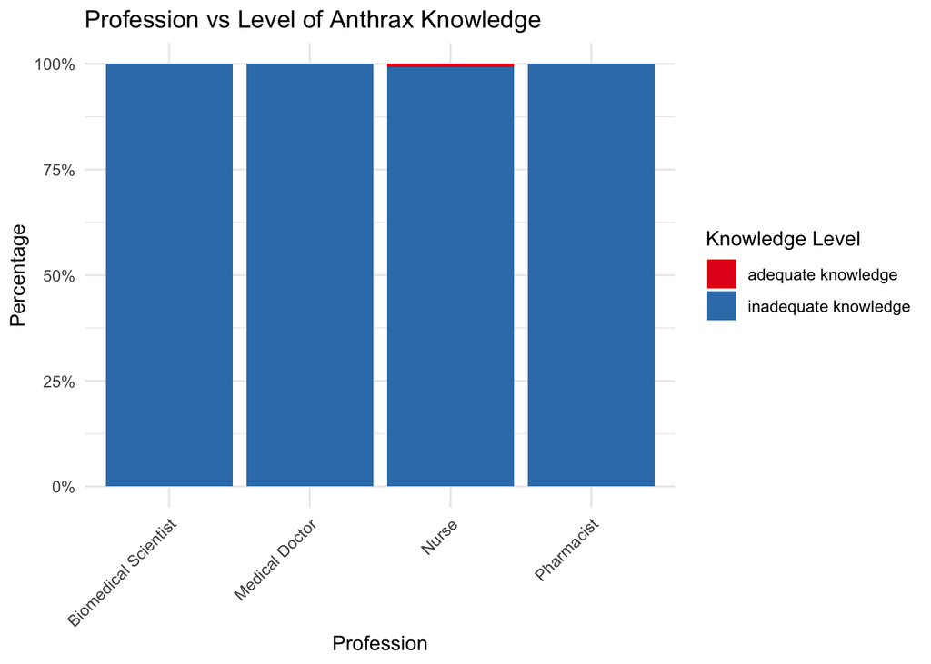

Profession vs Anthrax Knowledge Scores (Counts)

|  | 0 | 1 | 2 | 3 | 4 | 5 | 6 | 7 | 8 |
| --- | --- | --- | --- | --- | --- | --- | --- | --- | --- |
| Biomedical Scientist | 1 | 2 | 0 | 4 | 0 | 1 | 0 | 0 | 0 |
| Medical Doctor | 1 | 0 | 0 | 0 | 1 | 2 | 0 | 0 | 0 |
| Nurse | 13 | 16 | 23 | 33 | 22 | 16 | 8 | 3 | 1 |
| Pharmacist | 0 | 0 | 0 | 2 | 1 | 2 | 0 | 0 | 0 |

```
##              Df Sum Sq Mean Sq F value Pr(>F)
## profession    3    9.1   3.024   0.945  0.421
## Residuals   148  473.9   3.202
```

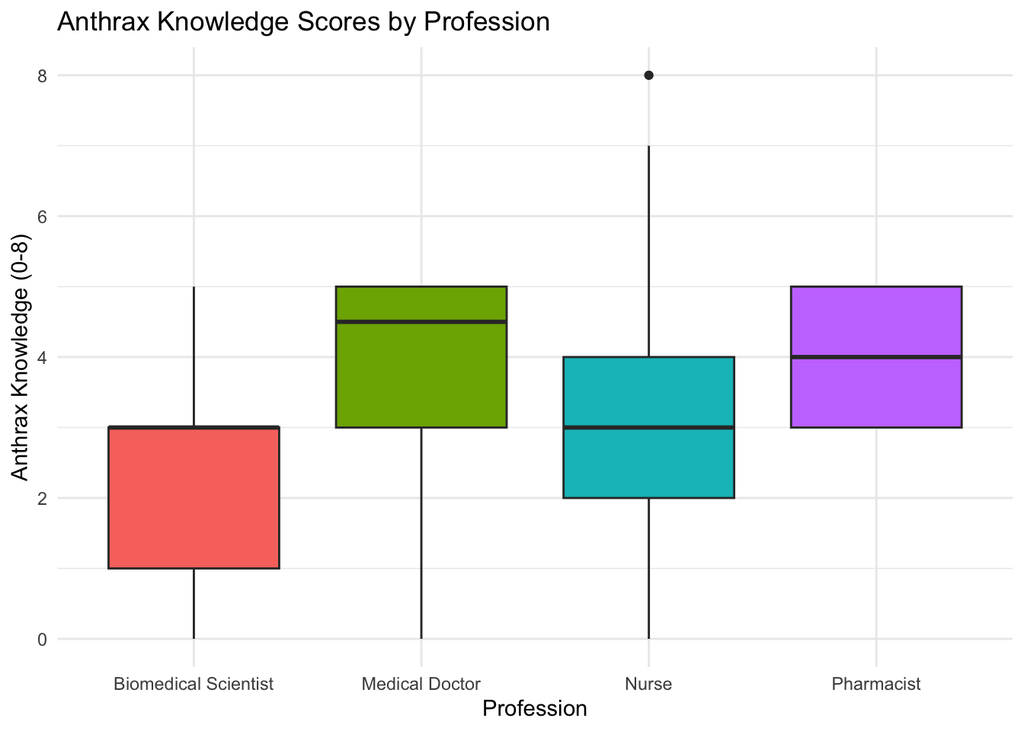

Profession vs Level of Rabies Knowledge

|  | adequate knowledge | inadequate knowledge |
| --- | --- | --- |
| Biomedical Scientist | 0 | 8 |
| Medical Doctor | 0 | 4 |
| Nurse | 2 | 133 |
| Pharmacist | 0 | 5 |

Profession vs Level of Rabies Knowledge

|  | adequate knowledge | inadequate knowledge |
| --- | --- | --- |
| Biomedical Scientist | 0.000000 | 100.00000 |
| Medical Doctor | 0.000000 | 100.00000 |
| Nurse | 1.481481 | 98.51852 |
| Pharmacist | 0.000000 | 100.00000 |

```
##
##  Fisher's Exact Test for Count Data
##
## data:  prof_rabies_cat
## p-value = 1
## alternative hypothesis: two.sided
```

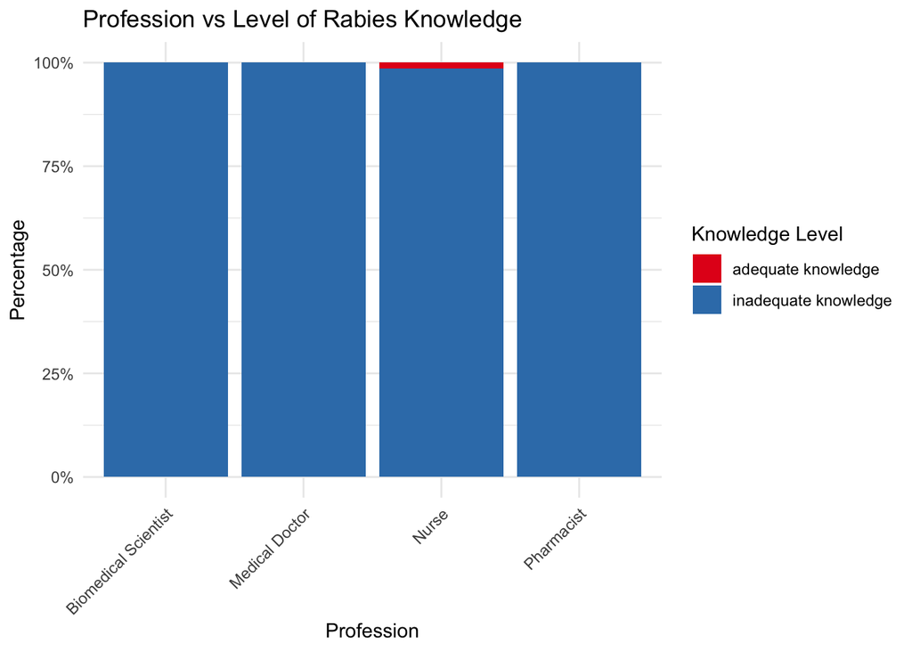

Profession vs Rabies Knowledge Scores (Counts)

|  | 0 | 1 | 2 | 3 | 4 | 5 | 6 | 7 | 8 |
| --- | --- | --- | --- | --- | --- | --- | --- | --- | --- |
| Biomedical Scientist | 0 | 0 | 2 | 2 | 3 | 0 | 1 | 0 | 0 |
| Medical Doctor | 0 | 0 | 1 | 0 | 0 | 0 | 3 | 0 | 0 |
| Nurse | 5 | 5 | 8 | 31 | 35 | 25 | 21 | 3 | 2 |
| Pharmacist | 0 | 0 | 1 | 0 | 2 | 1 | 1 | 0 | 0 |

```
##              Df Sum Sq Mean Sq F value Pr(>F)
## profession    3    6.2   2.057   0.783  0.505
## Residuals   148  388.8   2.627
```

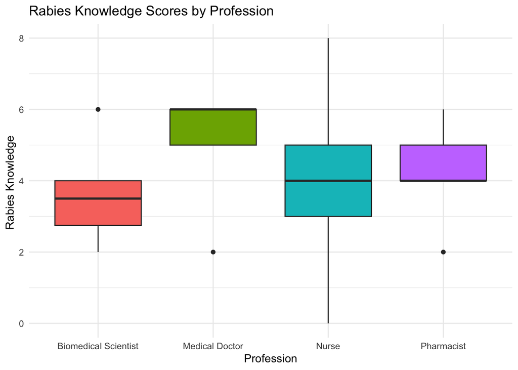

Profession vs Brucellosis Knowledge Level

|  | inadequate knowledge |
| --- | --- |
| Biomedical Scientist | 8 |
| Medical Doctor | 4 |
| Nurse | 135 |
| Pharmacist | 5 |

Note:  
All respondents had ‘inadequate knowledge’ - no statistical test possible

Profession vs Brucellosis Knowledge Scores (Counts)

|  | 0 | 1 | 2 | 3 | 4 | 5 | 6 | 7 |
| --- | --- | --- | --- | --- | --- | --- | --- | --- |
| Biomedical Scientist | 2 | 0 | 1 | 1 | 2 | 1 | 1 | 0 |
| Medical Doctor | 1 | 0 | 0 | 0 | 0 | 1 | 1 | 1 |
| Nurse | 45 | 23 | 19 | 20 | 13 | 7 | 5 | 3 |
| Pharmacist | 0 | 1 | 1 | 3 | 0 | 0 | 0 | 0 |

```
##              Df Sum Sq Mean Sq F value Pr(>F)
## profession    3   34.2  11.388   3.019 0.0318 *
## Residuals   148  558.3   3.772
## ---
## Signif. codes:  0 '***' 0.001 '**' 0.01 '*' 0.05 '.' 0.1 ' ' 1
```

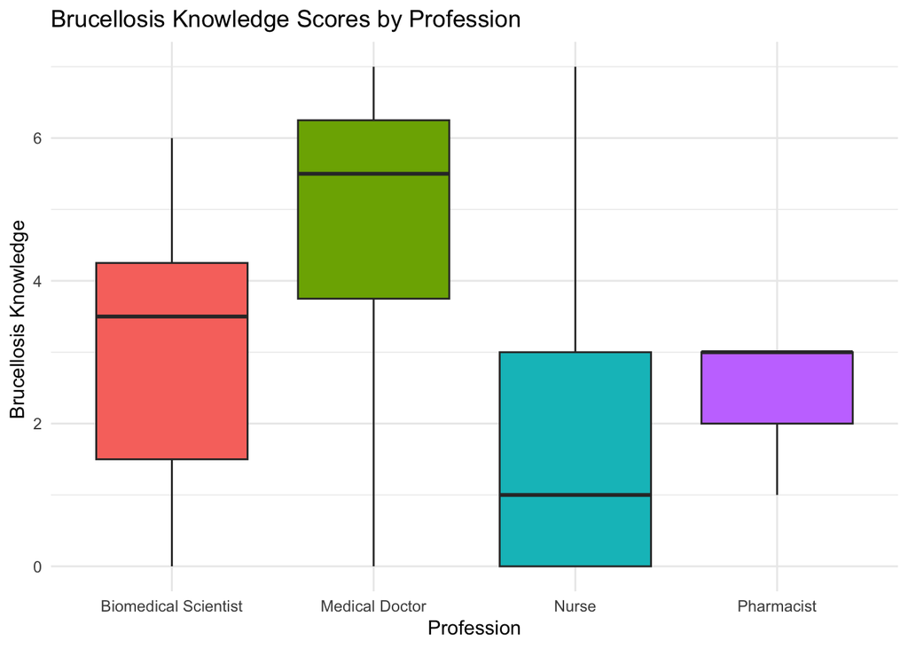

Profession vs Trypanosomiasis Knowledge Level

|  | inadequate knowledge |
| --- | --- |
| Biomedical Scientist | 8 |
| Medical Doctor | 4 |
| Nurse | 135 |
| Pharmacist | 5 |

Note:  
All respondents had ‘inadequate knowledge’ - no statistical test possible

Profession vs Trypanosomiasis Knowledge Scores (Counts)

|  | 0 | 1 | 2 | 3 | 4 | 5 | 6 | 7 |
| --- | --- | --- | --- | --- | --- | --- | --- | --- |
| Biomedical Scientist | 0 | 0 | 1 | 0 | 2 | 4 | 1 | 0 |
| Medical Doctor | 0 | 1 | 0 | 0 | 0 | 1 | 1 | 1 |
| Nurse | 18 | 16 | 28 | 22 | 24 | 19 | 8 | 0 |
| Pharmacist | 0 | 1 | 0 | 1 | 3 | 0 | 0 | 0 |

```
##              Df Sum Sq Mean Sq F value Pr(>F)
## profession    3   35.8  11.945   3.862 0.0107 *
## Residuals   148  457.7   3.093
## ---
## Signif. codes:  0 '***' 0.001 '**' 0.01 '*' 0.05 '.' 0.1 ' ' 1
```

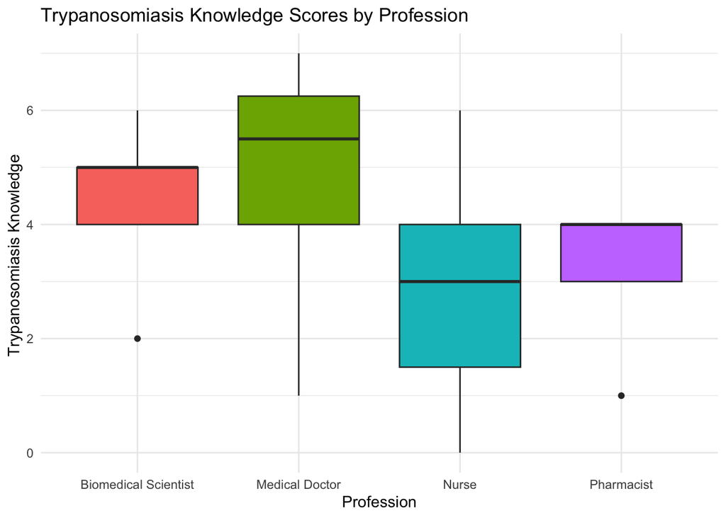

Profession vs TB Knowledge Level

|  | inadequate knowledge |
| --- | --- |
| Biomedical Scientist | 8 |
| Medical Doctor | 4 |
| Nurse | 135 |
| Pharmacist | 5 |

Note:  
All respondents had ‘inadequate knowledge’ - no statistical test possible

Profession vs TB Knowledge Scores (Counts)

|  | 0 | 1 | 2 | 3 | 4 | 5 | 6 | 7 |
| --- | --- | --- | --- | --- | --- | --- | --- | --- |
| Biomedical Scientist | 0 | 0 | 0 | 2 | 1 | 4 | 0 | 1 |
| Medical Doctor | 0 | 0 | 0 | 0 | 0 | 0 | 4 | 0 |
| Nurse | 14 | 11 | 15 | 22 | 18 | 24 | 15 | 16 |
| Pharmacist | 0 | 1 | 0 | 0 | 2 | 2 | 0 | 0 |

```
##              Df Sum Sq Mean Sq F value Pr(>F)
## profession    3   25.8   8.599   1.975   0.12
## Residuals   148  644.4   4.354
```

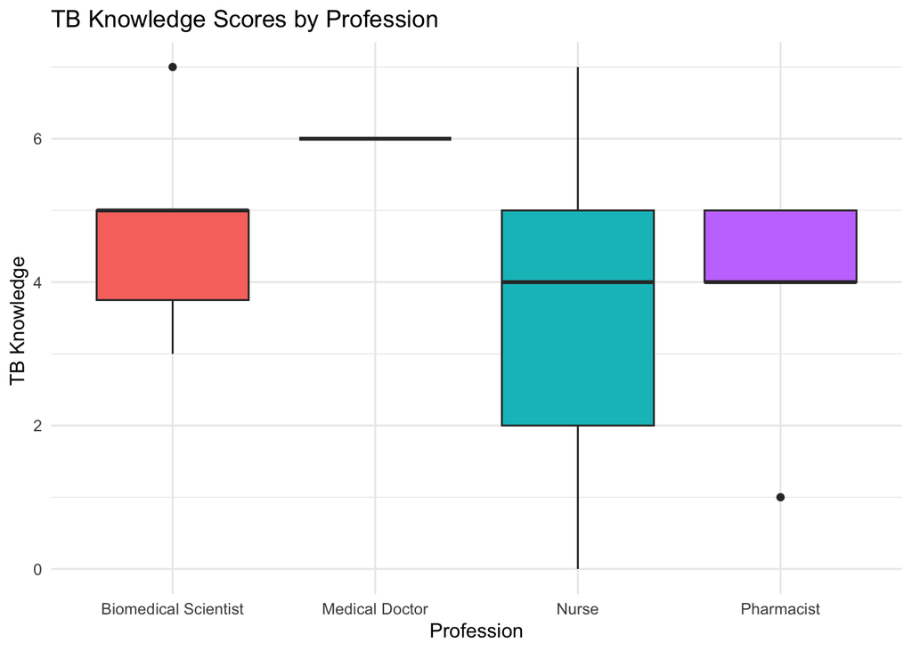

- Observations
1. Profession vs. Anthrax Knowledge

Categorical Outcome (anthrax_knowledge_cat, adequate/inadequate):

Cross-tabulation (Counts and Proportions):

Biomedical Scientist: 0 adequate, 8 inadequate (100% inadequate).

Medical Doctor: 0 adequate, 4 inadequate (100% inadequate).

Nurse: 1 adequate (0.7%), 134 inadequate (99.3%).

Pharmacist: 0 adequate, 5 inadequate (100% inadequate).

Nearly invariant: Only 1 Nurse has adequate knowledge, making statistical analysis unreliable.

Fisher’s Exact Test: p = 1.0.

No significant association between profession and anthrax knowledge level.

The invariant outcome (151/152 inadequate) and small non-Nurse sample sizes cabnt make meaningful differences.

Visualization (Stacked Bar Plot): All professions show nearly 100% inadequate knowledgeno.

The single adequate case (Nurse) is barely visible

Numeric Outcome (anthrax_knowledge_total, 0–8):

Cross-tabulation (Counts):

Biomedical Scientist: Scores range from 0 (1) to 5 (1), with a peak at 3 (4/8).

Medical Doctor: Scores at 0 (1), 4 (1), 5 (2), relatively high.

Pharmacist: Scores at 3 (2), 4 (1), 5 (2), mid-range.

Nurses show the broadest distribution due to their large sample size.

ANOVA Test: F(3, 148) = 0.945, p = 0.421.

No significant differences in anthrax knowledge scores across professions.

The low F-value suggests minimal variation by profession.

Nurses have the widest spread (0–8), reflecting sample size.

Overlapping distributions indicate no clear profession-based differences.

Observation: Anthrax knowledge is generally low (mean 3.02/8 from summary), with nearly all respondents classified as inadequate (151/152).

No significant profession-based differences in either categorical or numeric outcomes.

2. Profession vs. Rabies Knowledge

Categorical Outcome (rabies_knowledge_cat, adequate/inadequate):

Cross-tabulation (Counts and Proportions):

Biomedical Scientist: 0 adequate, 8 inadequate (100% inadequate).

Medical Doctor: 0 adequate, 4 inadequate (100% inadequate).

Nurse: 2 adequate (1.5%), 133 inadequate (98.5%).

Pharmacist: 0 adequate, 5 inadequate (100% inadequate).

Nearly invariant: Only 2 Nurses have adequate knowledge.

Fisher’s Exact Test: p = 1.0.

No significant association between profession and rabies knowledge level.

The sparse adequate cases (2/152) and small non-Nurse groups limit analysis.

Visualization (Stacked Bar Plot): All professions show nearly 100% inadequate knowledge.

The two adequate cases (Nurses) are minimally visible.

Numeric Outcome (rabies_knowledge_total, 0–8):

Cross-tabulation (Counts):

Biomedical Scientist: Scores range from 2 (2) to 6 (1), with a peak at 4 (3/8).

Medical Doctor: Scores at 2 (1), 6 (3), relatively high.

Pharmacist: Scores at 2 (1), 4 (2), 5 (1), 6 (1), mid-range.

ANOVA Test: F(3, 148) = 0.783, p = 0.505.

No significant differences in rabies knowledge scores across professions.

Visualization (Boxplot): Medians: Medical Doctors around 6, others around 4.

Nurses show the widest spread (0–8).

Overlapping distributions suggest no clear differences.

Observation: Rabies knowledge is the highest among the five zoonoses (mean 4.02/8), but still predominantly inadequate (150/152).

No significant profession-based differences.

3. Profession vs. Brucellosis Knowledge

Categorical Outcome (brucellosis_knowledge_cat, inadequate):

Cross-tabulation:

All professions: 100% inadequate (8 Biomedical Scientists, 4 Medical Doctors, 135 Nurses, 5 Pharmacists).

Completely invariant: No adequate knowledge cases.

Statistical Test: No test possible due to zero variation.

Numeric Outcome (brucellosis_knowledge_total, 0–7):

Cross-tabulation (Counts):

Biomedical Scientist: Scores range from 0 (2) to 6 (1), spread across 0–6.

Medical Doctor: Scores at 0 (1), 5 (1), 6 (1), 7 (1), high.

Nurse: Scores range from 0 (45) to 7 (3), with a peak at 0 (45).

Pharmacist: Scores at 1 (1), 2 (1), 3 (3), low to mid-range.

ANOVA Test: F(3, 148) = 3.019, p = 0.0318 (significant at α = 0.05).

Significant differences in brucellosis knowledge scores across professions.

The first significant result among the zoonoses analyses.

Nurses have a wide spread (0–7), Pharmacists are concentrated at lower scores.

Observation: Brucellosis knowledge is the lowest (mean 2.06/7), with all respondents classified as inadequate.

The significant ANOVA result suggests profession-based differences in numeric scores, with Medical Doctors scoring highest, followed by Biomedical Scientists.

4. Profession vs. Trypanosomiasis Knowledge

Categorical Outcome (trypanosomiasis_knowledge_cat, inadequate):

Cross-tabulation:

All professions: 100% inadequate (8 Biomedical Scientists, 4 Medical Doctors, 135 Nurses, 5 Pharmacists).

Completely invariant.

Statistical Test: No test possible.

Numeric Outcome (trypanosomiasis_knowledge_total, 0–7):

Cross-tabulation (Counts):

Biomedical Scientist: Scores range from 2 (1) to 6 (1), with a peak at 5 (4/8).

Medical Doctor: Scores at 1 (1), 5 (1), 6 (1), 7 (1), high.

Pharmacist: Scores at 1 (1), 3 (1), 4 (3), low to mid-range.

ANOVA Test: F(3, 148) = 3.862, p = 0.0107 (significant at α = 0.05).

Significant differences in trypanosomiasis knowledge scores across professions.

Visualization (Boxplot): Medians: Medical Doctors and Biomedical Scientists highest (around 5–6), Nurses and Pharmacists lower (around 3).

Nurses show a wide spread (0–6).

Observation: Trypanosomiasis knowledge is moderate (mean 2.95/7), but all respondents are inadequate.

Significant profession-based differences in numeric scores, with Medical Doctors and Biomedical Scientists scoring higher.

5. Profession vs. Tuberculosis (TB) Knowledge

Categorical Outcome (tb_knowledge_cat, inadequate):

Cross-tabulation:

All professions: 100% inadequate (8 Biomedical Scientists, 4 Medical Doctors, 135 Nurses, 5 Pharmacists).

Completely invariant.

Statistical Test: No test possible.

Numeric Outcome (tb_knowledge_total, 0–7):

Cross-tabulation (Counts):

Biomedical Scientist: Scores range from 3 (2) to 7 (1), with a peak at 5 (4/8).

Medical Doctor: All scores at 6 (4/4), consistently high.

Nurse: Scores range from 0 (14) to 7 (16), with peaks at 3 (22) and 5 (24).

Pharmacist: Scores at 1 (1), 4 (2), 5 (2), mid-range.

ANOVA Test: F(3, 148) = 1.975, p = 0.12.

No significant differences in TB knowledge scores across professions.

Visualization (Boxplot): Medians: Medical Doctors highest (6), Biomedical Scientists around 5, Nurses and Pharmacists around 3–4.

Nurses have the widest spread (0–7).

Observation: TB knowledge is relatively strong (mean 3.82/7), but all respondents are inadequate.

No significant profession-based differences, though Medical Doctors consistently score high (all 6).

Profession vs One Health Knowledge (Counts)

|  | high knowledge | low knowledge |
| --- | --- | --- |
| Biomedical Scientist | 5 | 3 |
| Medical Doctor | 4 | 0 |
| Nurse | 106 | 29 |
| Pharmacist | 5 | 0 |

Profession vs One Health Knowledge (Percentages)

|  | high knowledge | low knowledge |
| --- | --- | --- |
| Biomedical Scientist | 62.50000 | 37.50000 |
| Medical Doctor | 100.00000 | 0.00000 |
| Nurse | 78.51852 | 21.48148 |
| Pharmacist | 100.00000 | 0.00000 |

```
##
##  Fisher's exact test: p-value = 0.357
```

Profession vs Knowledge of One Health (Counts)

[output not shown]

```
##             profession one_health_knowledge_total.mean
## 1 Biomedical Scientist                        9.250000
## 2       Medical Doctor                       12.500000
## 3                Nurse                        9.044444
## 4           Pharmacist                       10.200000
##   one_health_knowledge_total.sd one_health_knowledge_total.n
## 1                      4.803273                     8.000000
## 2                      2.380476                     4.000000
## 3                      3.429170                   135.000000
## 4                      1.923538                     5.000000
```

ANOVA Results for One Health Knowledge by Profession

|  | Df | Sum Sq | Mean Sq | F value | Pr(>F) |
| --- | --- | --- | --- | --- | --- |
| profession | 3 | 51.80877 | 17.26959 | 1.4448 | 0.232143 |
| Residuals | 148 | 1769.03333 | 11.95293 | NA | NA |

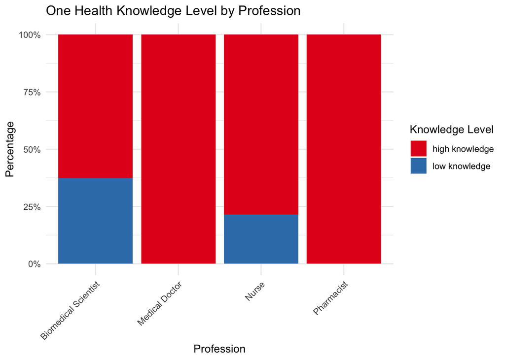

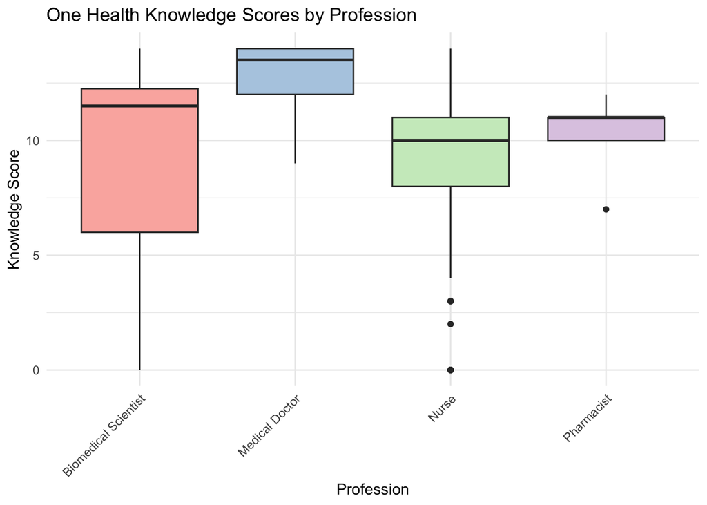

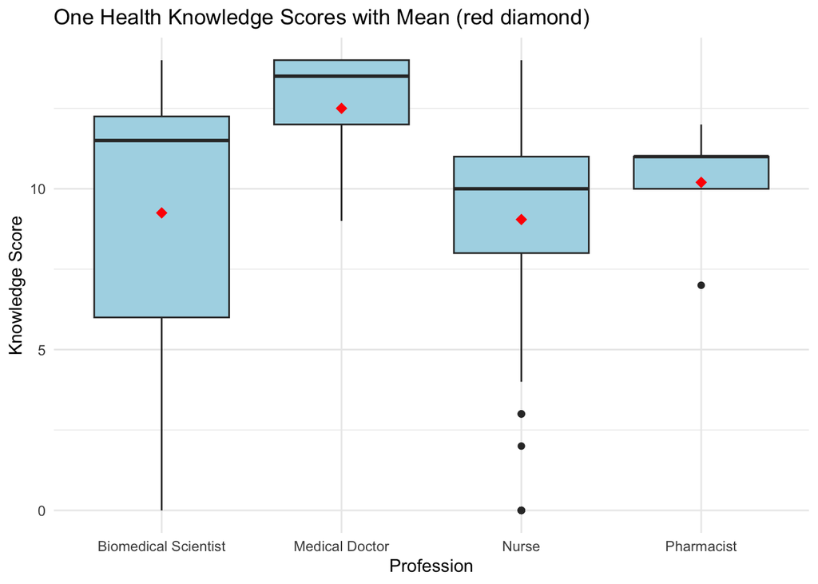

```
##
##
## ## Analysis for: one_health_definition
```

```
##
##  Fisher's exact test: p-value = 0.296
##
##
## ## Analysis for: biodiversity_one_health
```

```
##
##  Fisher's exact test: p-value = 0.331
##
##
## ## Analysis for: deforestation_one_health
```

```
##
##  Fisher's exact test: p-value = 0.673
##
##
## ## Analysis for: antibiotic_resistance_one_health
```

```
##
##  Fisher's exact test: p-value = 0.678
##
##
## ## Analysis for: armed_conflict_one_health
```

```
##
##  Fisher's exact test: p-value = 0.006
##
##
## ## Analysis for: zoonosis_one_health
```

```
##
##  Fisher's exact test: p-value = 0.363
##
##
## ## Analysis for: food_safety_one_health
```

```
##
##  Fisher's exact test: p-value = 0.471
##
##
## ## Analysis for: urbanization_one_health
```

```
##
##  Fisher's exact test: p-value = 0.69
##
##
## ## Analysis for: animal_husbandry_one_health
```

```
##
##  Fisher's exact test: p-value = 0.46
##
##
## ## Analysis for: mental_health_one_health
```

```
##
##  Fisher's exact test: p-value = 0.53
##
##
## ## Analysis for: non_communicable_diseases_one_health
```

```
##
##  Fisher's exact test: p-value = 0.881
##
##
## ## Analysis for: animal_welfare_one_health
```

```
##
##  Fisher's exact test: p-value = 0.17
##
##
## ## Analysis for: climate_change_one_health
```

```
##
##  Fisher's exact test: p-value = 0.519
##
##
## ## Analysis for: plant_pests_one_health
```

```
##
##  Fisher's exact test: p-value = 0.683
```

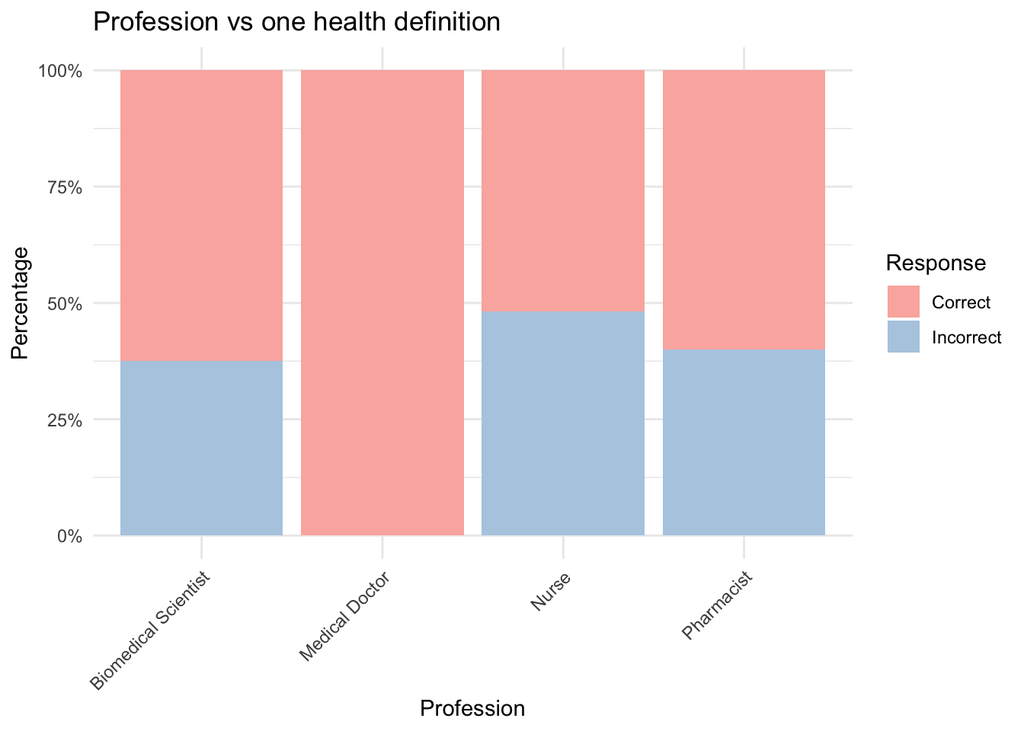

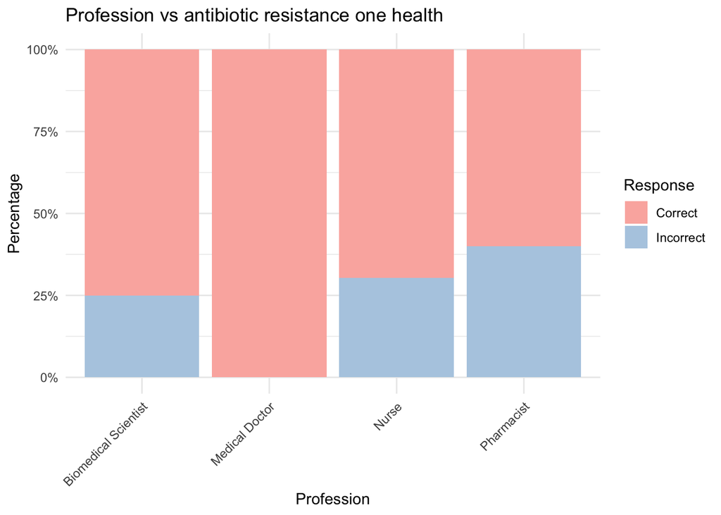

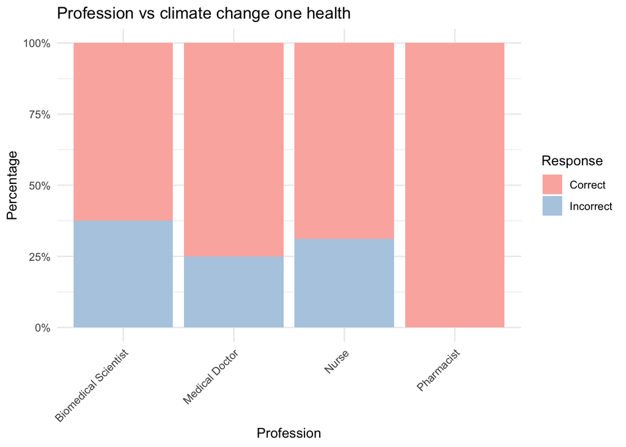

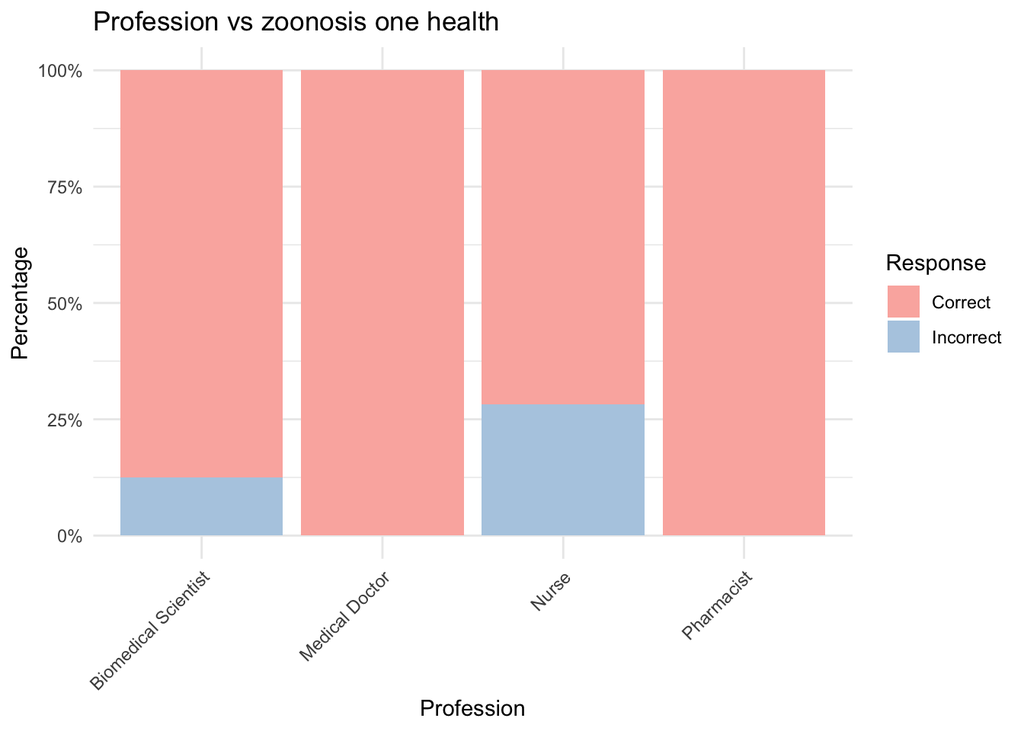

- Observations
1. Profession vs. One Health Knowledge Level

Cross-tabulation (Counts and Proportions):

Biomedical Scientist: 5 high (62.5%), 3 low (37.5%).

Medical Doctor: 4 high (100%), 0 low (0%).

Nurse: 106 high (78.5%), 29 low (21.5%).

Pharmacist: 5 high (100%), 0 low (0%).

High knowledge dominates, especially for Medical Doctors and Pharmacists (100%).

Fisher’s Exact Test: p = 0.357.

No significant association between profession and One Health knowledge level.

The high p-value suggests similar distributions of high/low knowledge across professions.

Visualization (Stacked Bar Plot): Medical Doctors and Pharmacists show 100% high knowledge.

Nurses and Biomedical Scientists have lower proportions of high knowledge (78.5% and 62.5%), with Biomedical Scientists showing the highest low knowledge proportion (37.5%).

The small sample sizes for Medical Doctors (4) and Pharmacists (5) limit reliability.

Observation: One Health knowledge is generally high (120/152 high, 78.9% from summary), but not significantly associated with profession.

Medical Doctors and Pharmacists appear to have perfect high knowledge, but small sample sizes reduce confidence.

2. Profession vs. One Health Knowledge Scores

Cross-tabulation (Counts):

Biomedical Scientist: Scores range from 0 (1) to 14 (1), with peaks at 11–13.

Nurses show the broadest distribution due to their large sample size.

Summary Statistics: Mean (SD, n): Biomedical Scientist: 9.25 (4.80, n=8).

Medical Doctor: 12.50 (2.38, n=4).

Nurse: 9.04 (3.43, n=135).

Pharmacist: 10.20 (1.92, n=5).

Medical Doctors have the highest mean score, followed by Pharmacists, while Nurses have the lowest.

ANOVA Test: F(3, 148) = 1.4448, p = 0.2321.

No significant differences in One Health knowledge scores across professions.

The moderate F-value suggests some variation, but the p-value indicates it’s not statistically significant.

Nurses have the widest spread (0–14), reflecting their sample size.

Overlapping distributions suggest no clear profession-based differences.

The boxplot with mean points (red diamonds) highlights Medical Doctors’ high mean (12.50).

Observation: One Health knowledge scores are strong (mean 9.18/14 from summary), with Medical Doctors scoring highest on average, but no significant differences by profession.

Small sample sizes for Medical Doctors (4) and Pharmacists (5) limit power to detect differences.

3. Profession vs. Individual One Health Issues

Overview: 14 binary variables (Correct/Incorrect) were analyzed, each representing knowledge of a specific One Health issue ( one_health_definition, zoonosis one health,… ).

Fisher’s exact test was used for all due to low expected counts (< 5) in contingency tables, driven by small profession group sizes.

Significant Result:

Armed Conflict (armed_conflict_one_health): p = 0.006 (significant at α = 0.05).

Counts: Biomedical Scientist: 3 Correct (37.5%), 5 Incorrect (62.5%).

Medical Doctor: 4 Correct (100%), 0 Incorrect.

Nurse: 53 Correct (39.3%), 82 Incorrect (60.7%).

Pharmacist: 2 Correct (40%), 3 Incorrect (60%).

Proportions: Medical Doctors have 100% Correct Knowledge, while others are around 37.5–40% Correct.

Observation: Significant profession-based differences, with Medical Doctors showing perfect knowledge, possibly due to specialized education or exposure to conflict-related health issues.

Non-Significant Results (p-values from Fisher’s exact test): one_health_definition: p = 0.296.

biodiversity_one_health: p = 0.331.

deforestation_one_health: p = 0.673.

antibiotic_resistance_one_health: p = 0.678.

zoonosis_one_health: p = 0.363.

food_safety_one_health: p = 0.471.

urbanization_one_health: p = 0.69.

mental_health_one_health: p = 0.53.

non_communicable_diseases_one_health: p = 0.881.

animal_welfare_one_health: p = 0.17.

climate_change_one_health: p = 0.519.

plant_pests_one_health: p = 0.683.

No significant associations for these issues, with p-values indicating similar Correct/Incorrect knowledge distributions across professions.

Nurses and Biomedical Scientists: ~50% Correct.

No significant difference (p = 0.296).

No significant difference (p = 0.678).

Climate Change: All professions: ~60–80% Correct, with Pharmacists at 100%.

No significant difference (p = 0.519).

No significant difference (p = 0.363).

Visualizations show high Correct knowledge proportions but no consistent profession-based patterns.

Observation: Only armed_conflict_one_health shows a significant association, driven by Medical Doctors’ perfect knowledge.

Other issues have high Correct knowledge ( zoonosis_one_health 74.4%, food_safety_one_health 76.3% from summary), but distributions are similar across professions.

```
##
##                        No Yes
##   Biomedical Scientist  4   4
##   Medical Doctor        3   1
##   Nurse                89  46
##   Pharmacist            5   0
```

```
##
##                               No       Yes
##   Biomedical Scientist  50.00000  50.00000
##   Medical Doctor        75.00000  25.00000
##   Nurse                 65.92593  34.07407
##   Pharmacist           100.00000   0.00000
```

```
##
##  Fisher's Exact Test for Count Data
##
## data:  prof_exp
## p-value = 0.3151
## alternative hypothesis: two.sided
```

Profession vs Experience with Zoonotic Diseases

|  | Count No | Count Yes | Percentage (%) No | Percentage (%) Yes |
| --- | --- | --- | --- | --- |
| Biomedical Scientist | 4 | 4 | 50.00000 | 50.00000 |
| Medical Doctor | 3 | 1 | 75.00000 | 25.00000 |
| Nurse | 89 | 46 | 65.92593 | 34.07407 |
| Pharmacist | 5 | 0 | 100.00000 | 0.00000 |

Note:  
Fisher’s exact test: p-value = 0.315

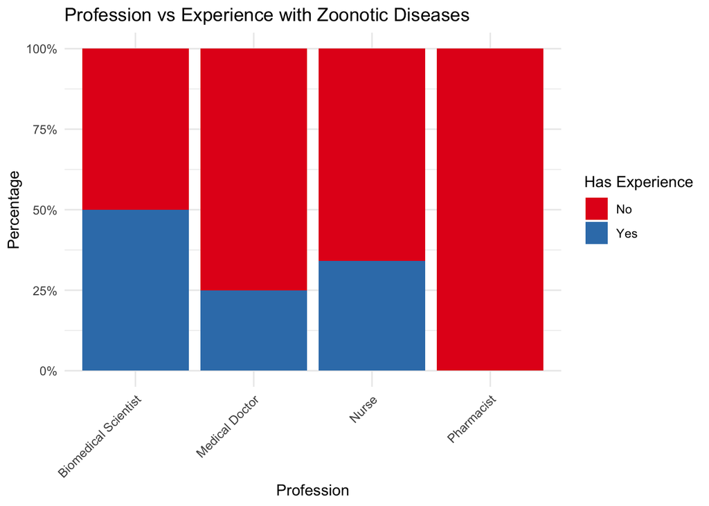

```
##
##                         0  1
##   Biomedical Scientist  6  2
##   Medical Doctor        4  0
##   Nurse                94 41
##   Pharmacist            5  0
```

```
##
##                                0         1
##   Biomedical Scientist  75.00000  25.00000
##   Medical Doctor       100.00000   0.00000
##   Nurse                 69.62963  30.37037
##   Pharmacist           100.00000   0.00000
```

```
##
##  Fisher's Exact Test for Count Data
##
## data:  prof_rab_enc
## p-value = 0.3865
## alternative hypothesis: two.sided
```

Profession vs Rabies Encounters

|  | Count 0 | Count 1 | Percentage (%) 0 | Percentage (%) 1 |
| --- | --- | --- | --- | --- |
| Biomedical Scientist | 6 | 2 | 75.00000 | 25.00000 |
| Medical Doctor | 4 | 0 | 100.00000 | 0.00000 |
| Nurse | 94 | 41 | 69.62963 | 30.37037 |
| Pharmacist | 5 | 0 | 100.00000 | 0.00000 |

Note:  
Fisher’s exact test: p-value = 0.386

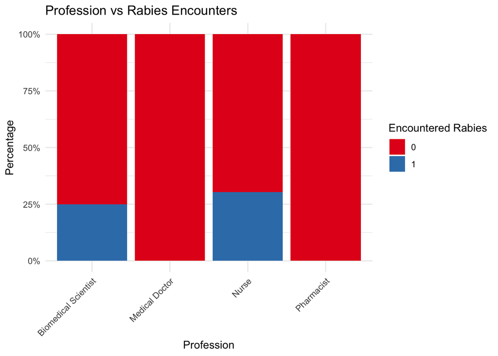

```
##
##
## # zoonosis_workshop Experience by Profession
##
##
## Table: zoonosis_workshop by Profession (Counts)
##
## |                     |  No| Yes|
## |:--------------------|---:|---:|
## |Biomedical Scientist |   7|   1|
## |Medical Doctor       |   3|   1|
## |Nurse                | 126|   9|
## |Pharmacist           |   5|   0|
##
##
## Table: zoonosis_workshop by Profession (%)
##
## |                     |        No|       Yes|
## |:--------------------|---------:|---------:|
## |Biomedical Scientist |  87.50000| 12.500000|
## |Medical Doctor       |  75.00000| 25.000000|
## |Nurse                |  93.33333|  6.666667|
## |Pharmacist           | 100.00000|  0.000000|
```

```
##
## Fisher's exact test p-value: 0.282
```

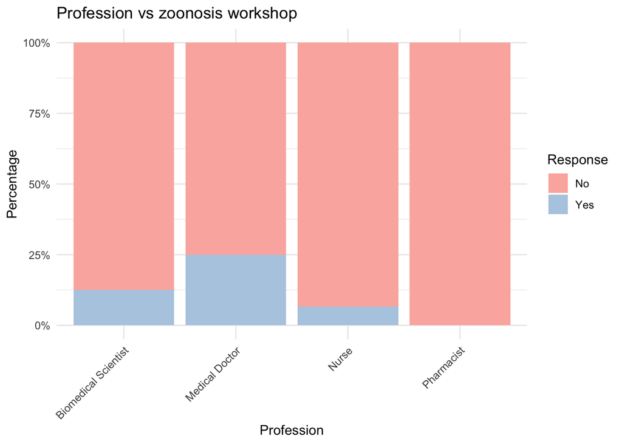

```
##
##
## # zoonosis_collaboration Experience by Profession
##
##
## Table: zoonosis_collaboration by Profession (Counts)
##
## |                     |  No| Yes|
## |:--------------------|---:|---:|
## |Biomedical Scientist |   8|   0|
## |Medical Doctor       |   4|   0|
## |Nurse                | 126|   9|
## |Pharmacist           |   5|   0|
##
##
## Table: zoonosis_collaboration by Profession (%)
##
## |                     |        No|      Yes|
## |:--------------------|---------:|--------:|
## |Biomedical Scientist | 100.00000| 0.000000|
## |Medical Doctor       | 100.00000| 0.000000|
## |Nurse                |  93.33333| 6.666667|
## |Pharmacist           | 100.00000| 0.000000|
```

```
##
## Fisher's exact test p-value: 1
```

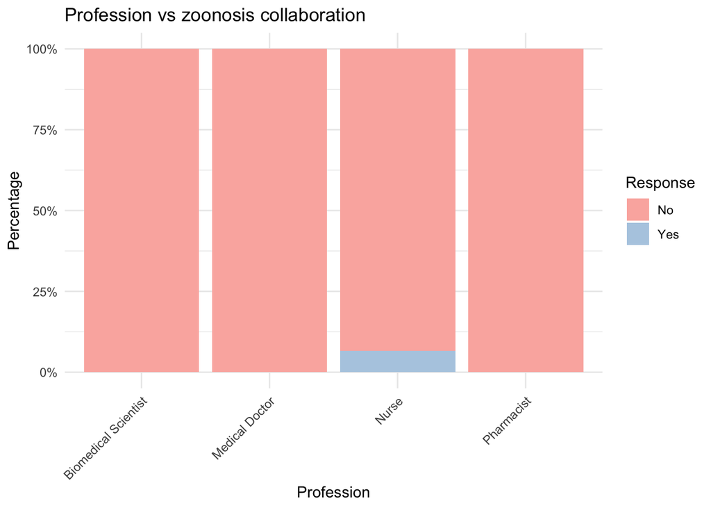

```
##
##
## # zoonotic_disease_encounter Experience by Profession
##
##
## Table: zoonotic_disease_encounter by Profession (Counts)
##
## |                     | No| Yes|
## |:--------------------|--:|---:|
## |Biomedical Scientist |  4|   4|
## |Medical Doctor       |  3|   1|
## |Nurse                | 89|  46|
## |Pharmacist           |  5|   0|
##
##
## Table: zoonotic_disease_encounter by Profession (%)
##
## |                     |        No|      Yes|
## |:--------------------|---------:|--------:|
## |Biomedical Scientist |  50.00000| 50.00000|
## |Medical Doctor       |  75.00000| 25.00000|
## |Nurse                |  65.92593| 34.07407|
## |Pharmacist           | 100.00000|  0.00000|
```

```
##
## Fisher's exact test p-value: 0.315
```

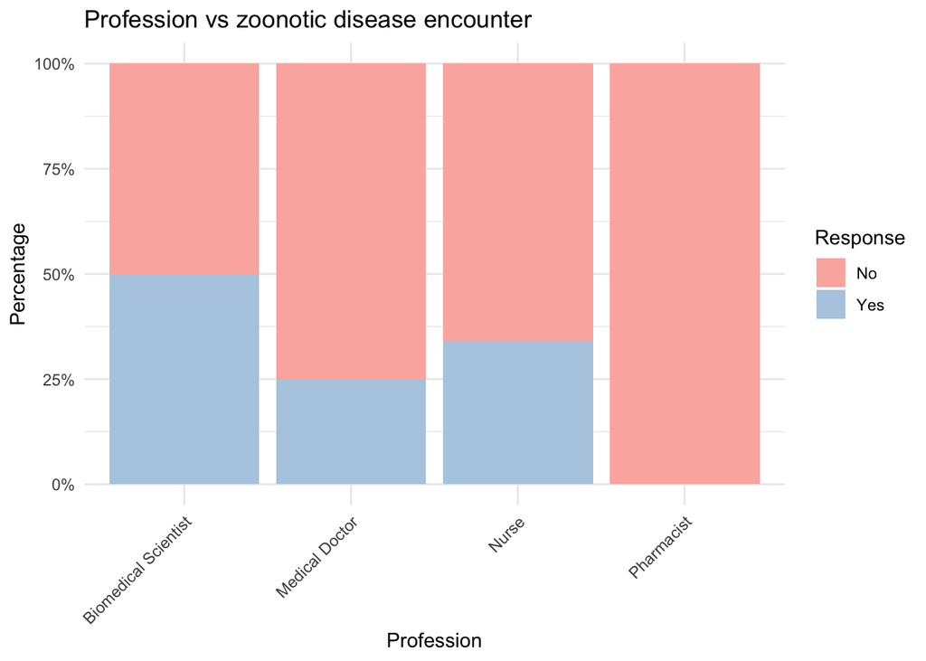

```
##
##
## # zoonosis_public_education Experience by Profession
##
##
## Table: zoonosis_public_education by Profession (Counts)
##
## |                     |  No| Yes|
## |:--------------------|---:|---:|
## |Biomedical Scientist |   8|   0|
## |Medical Doctor       |   4|   0|
## |Nurse                | 121|  14|
## |Pharmacist           |   5|   0|
##
##
## Table: zoonosis_public_education by Profession (%)
##
## |                     |        No|      Yes|
## |:--------------------|---------:|--------:|
## |Biomedical Scientist | 100.00000|  0.00000|
## |Medical Doctor       | 100.00000|  0.00000|
## |Nurse                |  89.62963| 10.37037|
## |Pharmacist           | 100.00000|  0.00000|
```

```
##
## Fisher's exact test p-value: 1
```

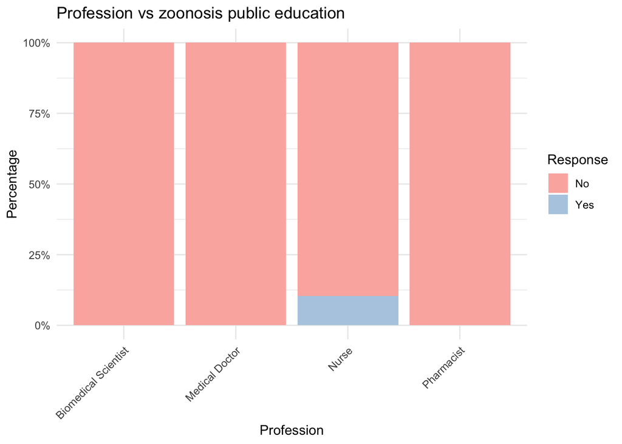

```
##
##
## # one_health_training Experience by Profession
##
##
## Table: one_health_training by Profession (Counts)
##
## |                     |  No| Yes|
## |:--------------------|---:|---:|
## |Biomedical Scientist |   4|   4|
## |Medical Doctor       |   4|   0|
## |Nurse                | 107|  28|
## |Pharmacist           |   5|   0|
##
##
## Table: one_health_training by Profession (%)
##
## |                     |        No|      Yes|
## |:--------------------|---------:|--------:|
## |Biomedical Scientist |  50.00000| 50.00000|
## |Medical Doctor       | 100.00000|  0.00000|
## |Nurse                |  79.25926| 20.74074|
## |Pharmacist           | 100.00000|  0.00000|
```

```
##
## Fisher's exact test p-value: 0.105
```

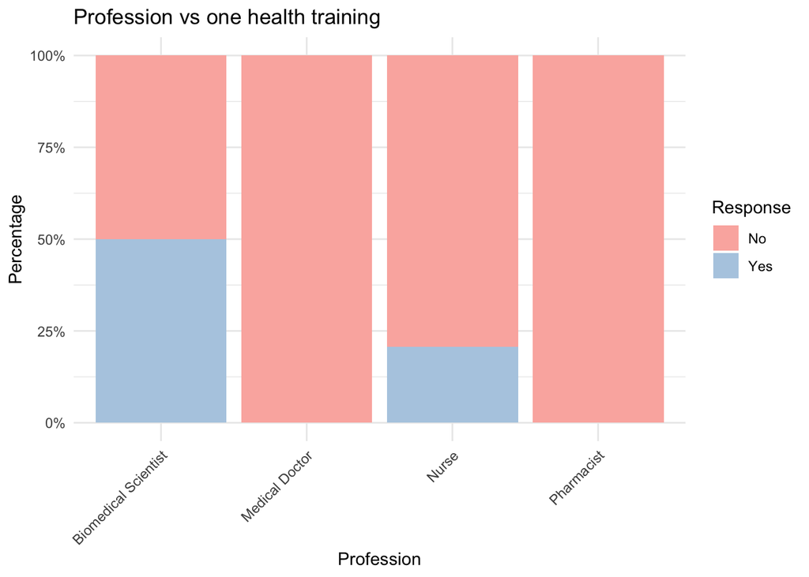

```
##
##
## # zoonosis_training Experience by Profession
##
##
## Table: zoonosis_training by Profession (Counts)
##
## |                     | No| Yes|
## |:--------------------|--:|---:|
## |Biomedical Scientist |  1|   7|
## |Medical Doctor       |  3|   1|
## |Nurse                | 89|  46|
## |Pharmacist           |  5|   0|
##
##
## Table: zoonosis_training by Profession (%)
##
## |                     |        No|      Yes|
## |:--------------------|---------:|--------:|
## |Biomedical Scientist |  12.50000| 87.50000|
## |Medical Doctor       |  75.00000| 25.00000|
## |Nurse                |  65.92593| 34.07407|
## |Pharmacist           | 100.00000|  0.00000|
```

```
##
## Fisher's exact test p-value: 0.004
```

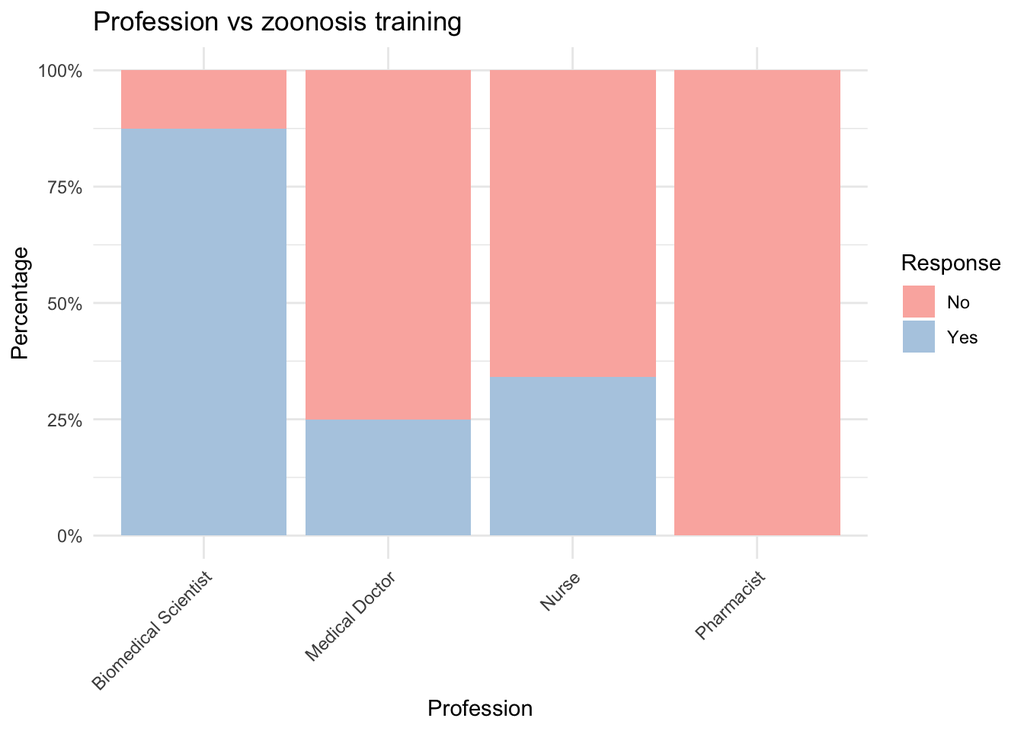

- Observations
1. Profession vs. Experience with Zoonotic Diseases

Cross-tabulation (Counts and Proportions):

Biomedical Scientist: 4 No (50%), 4 Yes (50%).

Medical Doctor: 3 No (75%), 1 Yes (25%).

Nurse: 89 No (65.9%), 46 Yes (34.1%).

Pharmacist: 5 No (100%), 0 Yes (0%).

Biomedical Scientists have the highest proportion of experience (50%), followed by Nurses (34.1%). Pharmacists report no encounters.

Fisher’s Exact Test: p = 0.3151.

No significant association between profession and zoonotic disease encounters.

The high p-value suggests similar encounter rates across professions.

Visualization (Stacked Bar Plot): Biomedical Scientists show an even split (50% Yes/No).

Nurses have ~34% Yes, Medical Doctors ~25% Yes, and Pharmacists 0% Yes.

Observation: Overall, 33.6% (51/152) report encounters (from summary), with Biomedical Scientists and Nurses most likely to have experience.

No significant profession-based differences, likely due to small non-Nurse sample sizes and low power.

2. Profession vs. Rabies Encounters

Cross-tabulation (Counts and Proportions):

Biomedical Scientist: 6 No (75%), 2 Yes (25%).

Medical Doctor: 4 No (100%), 0 Yes (0%).

Nurse: 94 No (69.6%), 41 Yes (30.4%).

Pharmacist: 5 No (100%), 0 Yes (0%).

Nurses have the highest proportion of rabies encounters (30.4%), followed by Biomedical Scientists (25%).

Fisher’s Exact Test: p = 0.3865.

No significant association between profession and rabies encounters.

The high p-value indicates similar encounter rates across professions.

Visualization (Stacked Bar Plot): Nurses show ~30% Yes, Biomedical Scientists ~25% Yes.

Medical Doctors and Pharmacists have 0% Yes, showing no rabies encounters.

Observation: Rabies is the most encountered zoonotic disease (28.3%, 43/152 from summary), primarily among Nurses.

No significant differences by profession, possibly due to sparse data (e.g., 0 encounters for Medical Doctors and Pharmacists).

3. Profession vs. Experience with Zoonoses and One Health (Six Variables) Overview:

Six binary variables were analyzed, each representing a type of experience or training.

Fisher’s exact test was used for all due to low expected counts (< 5), driven by small profession group sizes and low “Yes” responses.

Zoonosis Workshop (zoonosis_workshop): Counts and Proportions: Biomedical Scientist: 7 No (87.5%), 1 Yes (12.5%).

Medical Doctor: 3 No (75%), 1 Yes (25%).

Nurse: 126 No (93.3%), 9 Yes (6.7%).

Pharmacist: 5 No (100%), 0 Yes (0%).

Medical Doctors have the highest participation rate (25%), but overall participation is low (7.2%, 11/152).

Fisher’s Exact Test: p = 0.282.

Observation: No significant association. Low participation limits analysis power.

Zoonosis Collaboration (zoonosis_collaboration): Counts and Proportions: Biomedical Scientist: 8 No (100%), 0 Yes.

Medical Doctor: 4 No (100%), 0 Yes.

Nurse: 126 No (93.3%), 9 Yes (6.7%).

Pharmacist: 5 No (100%), 0 Yes.

Only Nurses report collaboration (all Rabies-related, per summary).

Fisher’s Exact Test: p = 1.0.

Observation: No significant association. Sparse “Yes” responses (5.9%, 9/152) and zero responses for non-Nurses block meaningful analysis.

Zoonosis Public Education:

Counts and Proportions: Biomedical Scientist: 8 No (100%), 0 Yes.

Medical Doctor: 4 No (100%), 0 Yes.

Nurse: 121 No (89.6%), 14 Yes (10.4%).

Pharmacist: 5 No (100%), 0 Yes.

Only Nurses report public education (mostly Rabies, per summary).

Fisher’s Exact Test: p = 1.0.

Observation: No significant association. Low engagement (9.2%, 14/152) and zero responses for non-Nurses limit analysis.

One Health Training:

Counts and Proportions:

Biomedical Scientist: 4 No (50%), 4 Yes (50%).

Medical Doctor: 4 No (100%), 0 Yes.

Nurse: 107 No (79.3%), 28 Yes (20.7%).

Pharmacist: 5 No (100%), 0 Yes.

Biomedical Scientists have the highest training rate (50%).

Fisher’s Exact Test: p = 0.105.

Observation: No significant association, but Biomedical Scientists’ high training rate is notable. Low overall training (21.1%, 32/152) and small sample sizes limit power.

Zoonosis Training:

Counts and Proportions:

Biomedical Scientist: 1 No (12.5%), 7 Yes (87.5%).

Medical Doctor: 3 No (75%), 1 Yes (25%).

Nurse: 89 No (65.9%), 46 Yes (34.1%).

Pharmacist: 5 No (100%), 0 Yes.

Biomedical Scientists have the highest training rate (87.5%), followed by Nurses (34.1%).

Fisher’s Exact Test: p = 0.004.

Observation: significant association, Biomedical Scientists have the highest training rate (87.5%)

```
##
##                         No Yes
##   Biomedical Scientist   8   0
##   Medical Doctor         4   0
##   Nurse                126   9
##   Pharmacist             5   0
```

```
##
##                                No        Yes
##   Biomedical Scientist 100.000000   0.000000
##   Medical Doctor       100.000000   0.000000
##   Nurse                 93.333333   6.666667
##   Pharmacist           100.000000   0.000000
```

```
##
##  Fisher's Exact Test for Count Data
##
## data:  prof_collab
## p-value = 1
## alternative hypothesis: two.sided
```

Profession vs Zoonoses Controlled in Collaboration

|  | Count No | Count Yes | Percentage (%) No | Percentage (%) Yes |
| --- | --- | --- | --- | --- |
| Biomedical Scientist | 8 | 0 | 100.00000 | 0.000000 |
| Medical Doctor | 4 | 0 | 100.00000 | 0.000000 |
| Nurse | 126 | 9 | 93.33333 | 6.666667 |
| Pharmacist | 5 | 0 | 100.00000 | 0.000000 |

Note:  
Fisher’s exact test: p-value = 1

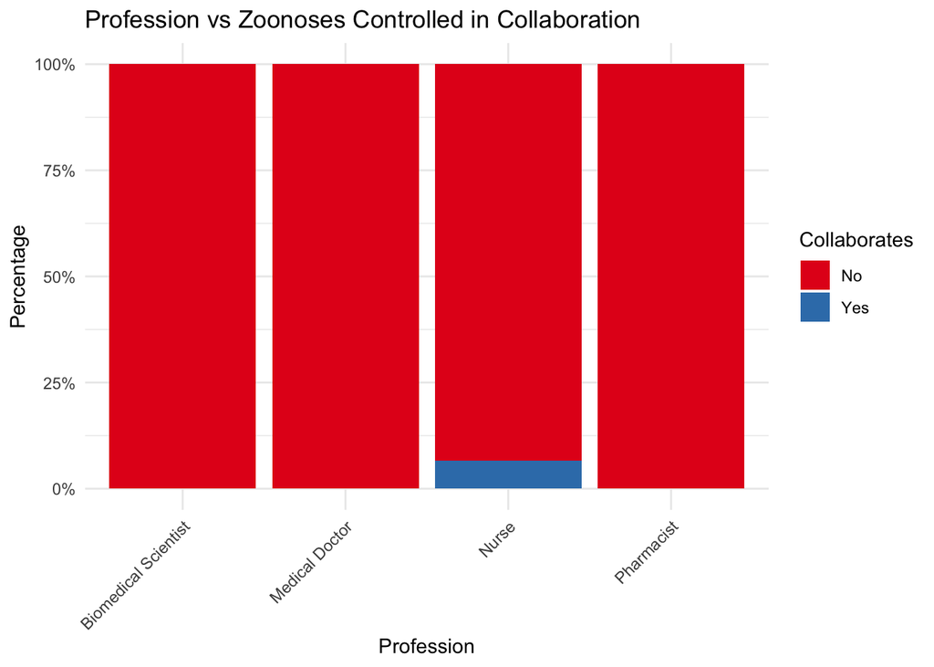

```
##
##                         No Yes
##   Biomedical Scientist   8   0
##   Medical Doctor         4   0
##   Nurse                121  14
##   Pharmacist             5   0
```

```
##
##                               No       Yes
##   Biomedical Scientist 100.00000   0.00000
##   Medical Doctor       100.00000   0.00000
##   Nurse                 89.62963  10.37037
##   Pharmacist           100.00000   0.00000
```

```
##
##  Fisher's Exact Test for Count Data
##
## data:  prof_edu
## p-value = 1
## alternative hypothesis: two.sided
```

Profession vs Zoonoses Covered in Public Health Education

|  | Count No | Count Yes | Percentage (%) No | Percentage (%) Yes |
| --- | --- | --- | --- | --- |
| Biomedical Scientist | 8 | 0 | 100.00000 | 0.00000 |
| Medical Doctor | 4 | 0 | 100.00000 | 0.00000 |
| Nurse | 121 | 14 | 89.62963 | 10.37037 |
| Pharmacist | 5 | 0 | 100.00000 | 0.00000 |

Note:  
Fisher’s exact test: p-value = 1

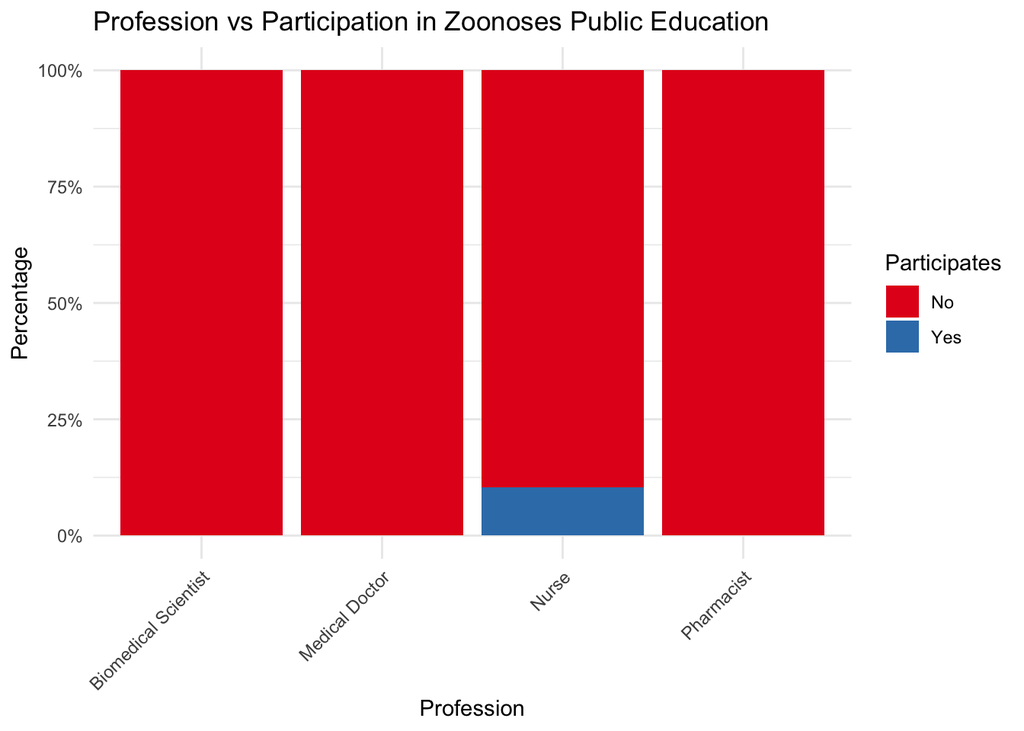

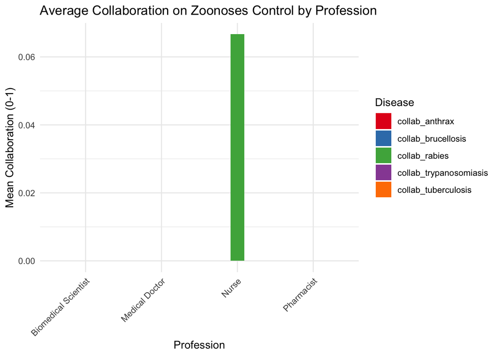

```
##
##
## # Collaboration on anthrax
##
##
## Table: Test for collab_anthrax
##
## |                           |Test           | ChiSq| df| p.value|
## |:--------------------------|:--------------|-----:|--:|-------:|
## |Kruskal-Wallis chi-squared |Kruskal-Wallis |   NaN|  3|     NaN|
##
##
## # Collaboration on rabies
##
##
## Table: Test for collab_rabies
##
## |                           |Test           | ChiSq| df| p.value|
## |:--------------------------|:--------------|-----:|--:|-------:|
## |Kruskal-Wallis chi-squared |Kruskal-Wallis |   1.2|  3|   0.754|
##
##
## # Collaboration on brucellosis
##
##
## Table: Test for collab_brucellosis
##
## |                           |Test           | ChiSq| df| p.value|
## |:--------------------------|:--------------|-----:|--:|-------:|
## |Kruskal-Wallis chi-squared |Kruskal-Wallis |   NaN|  3|     NaN|
##
##
## # Collaboration on trypanosomiasis
##
##
## Table: Test for collab_trypanosomiasis
##
## |                           |Test           | ChiSq| df| p.value|
## |:--------------------------|:--------------|-----:|--:|-------:|
## |Kruskal-Wallis chi-squared |Kruskal-Wallis |   NaN|  3|     NaN|
##
##
## # Collaboration on tuberculosis
##
##
## Table: Test for collab_tuberculosis
##
## |                           |Test           | ChiSq| df| p.value|
## |:--------------------------|:--------------|-----:|--:|-------:|
## |Kruskal-Wallis chi-squared |Kruskal-Wallis |   NaN|  3|     NaN|
```

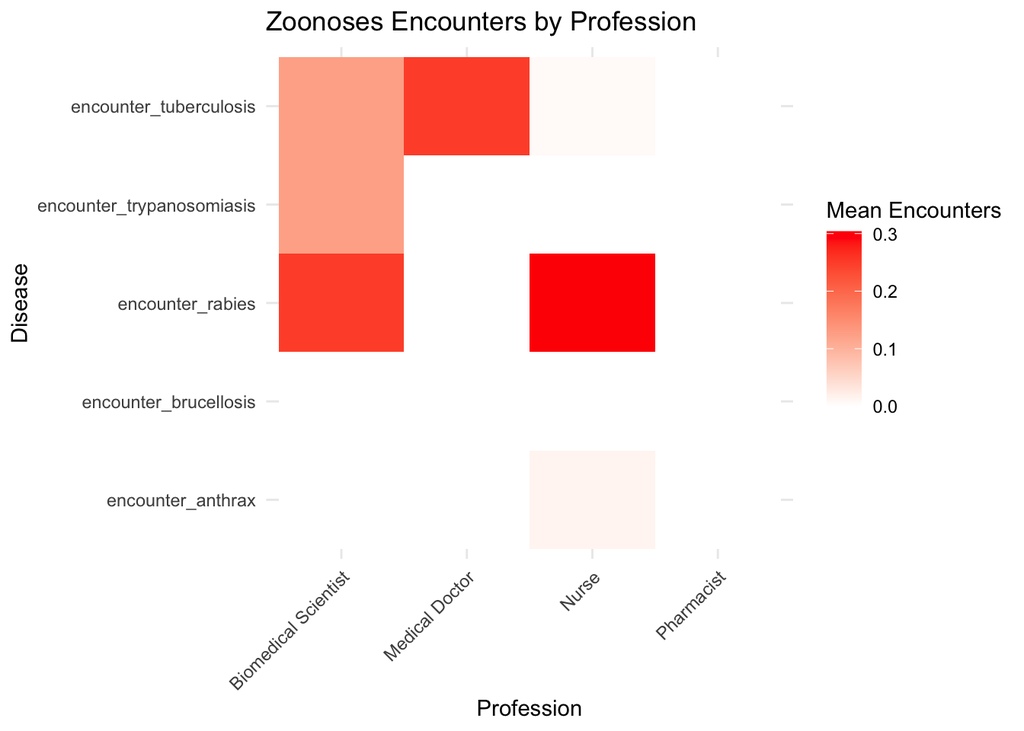

```
##
##
## # Encounters with anthrax
##
##
## Table: Test for encounter_anthrax
##
## |                           |Test           | ChiSq| df| p.value|
## |:--------------------------|:--------------|-----:|--:|-------:|
## |Kruskal-Wallis chi-squared |Kruskal-Wallis |  0.25|  3|   0.969|
##
##
## # Encounters with rabies
##
##
## Table: Test for encounter_rabies
##
## |                           |Test           | ChiSq| df| p.value|
## |:--------------------------|:--------------|-----:|--:|-------:|
## |Kruskal-Wallis chi-squared |Kruskal-Wallis |  3.86|  3|   0.277|
##
##
## # Encounters with brucellosis
##
##
## Table: Test for encounter_brucellosis
##
## |                           |Test           | ChiSq| df| p.value|
## |:--------------------------|:--------------|-----:|--:|-------:|
## |Kruskal-Wallis chi-squared |Kruskal-Wallis |   NaN|  3|     NaN|
##
##
## # Encounters with trypanosomiasis
##
##
## Table: Test for encounter_trypanosomiasis
##
## |                           |Test           | ChiSq| df| p.value|
## |:--------------------------|:--------------|-----:|--:|-------:|
## |Kruskal-Wallis chi-squared |Kruskal-Wallis |    18|  3|       0|
##
##
## # Encounters with tuberculosis
##
##
## Table: Test for encounter_tuberculosis
##
## |                           |Test           | ChiSq| df| p.value|
## |:--------------------------|:--------------|-----:|--:|-------:|
## |Kruskal-Wallis chi-squared |Kruskal-Wallis |  16.6|  3|   0.001|
```

Collaboration Summary: Mean collaboration rates for collab_anthrax, collab_rabies, visualized as a dodged bar plot.

Encounter Summary: Mean encounter rates for encounter_anthrax, encounter_rabies, etc., visualized as a heatmap.

Kruskal-Wallis Tests: Non-parametric tests for collaboration and encounter variables.

Collaboration Summary and Visualization Summary: Variables: collab_anthrax, collab_rabies, collab_brucellosis, collab_trypanosomiasis, collab_tuberculosis.

Only collab_rabies has non-zero responses (mean = 0.067 for Nurses, 0 for others).

Others are all 0 (no collaboration).

Visualization (Dodged Bar Plot):

Only Nurses show non-zero mean collaboration (~0.067 for Rabies).

All other professions and diseases show zero collaboration.

Plot highlights Nurses’ exclusive but low collaboration on Rabies.

Kruskal-Wallis Tests: collab_rabies: ChiSq = 1.2, df = 3, p = 0.754 (not significant).

Others (collab_anthrax, collab_brucellosis, collab_trypanosomiasis, collab_tuberculosis): NaN (no variation, all 0).

No significant differences, consistent with Fisher’s test (p = 1.0).

Observation: Collaboration is limited to Rabies and Nurses, with no profession-based differences.

Encounter Summary and Visualization Summary: Variables: encounter_anthrax (2 Yes), encounter_rabies (43 Yes), encounter_brucellosis (0 Yes), encounter_trypanosomiasis (1 Yes), encounter_tuberculosis (3 Yes).

Rabies dominates encounters, with minimal activity for other diseases.

Kruskal-Wallis Tests: encounter_anthrax: ChiSq = 0.25, df = 3, p = 0.969 (not significant).

encounter_rabies: ChiSq = 3.86, df = 3, p = 0.277 (not significant).

encounter_brucellosis: NaN (no variation, all 0).

encounter_trypanosomiasis: ChiSq = 18, df = 3, p = 0.000 (significant).

encounter_tuberculosis: ChiSq = 16.6, df = 3, p = 0.001 (significant).

No significant differences for encounter_rabies or encounter_anthrax, consistent with Fisher’s tests (p = 0.386 and p ≈ 1.0).

- Key trends so far

Knowledge: Strong for prioritized zoonoses (87.5% high) and One Health (78.9% high), moderate for general zoonosis (46.1% high). Medical Doctors and Biomedical Scientists often score higher, but small sample sizes limit significance.

Experience: Low engagement in workshops (7.2%), collaboration (5.9%), and public education (9.2%). Biomedical Scientists lead in training, Nurses in encounters.

Nurse Dominance: Nurses drive most outcomes due to sample size (135/152).

Pharmacists: Minimal involvement across all outcomes.

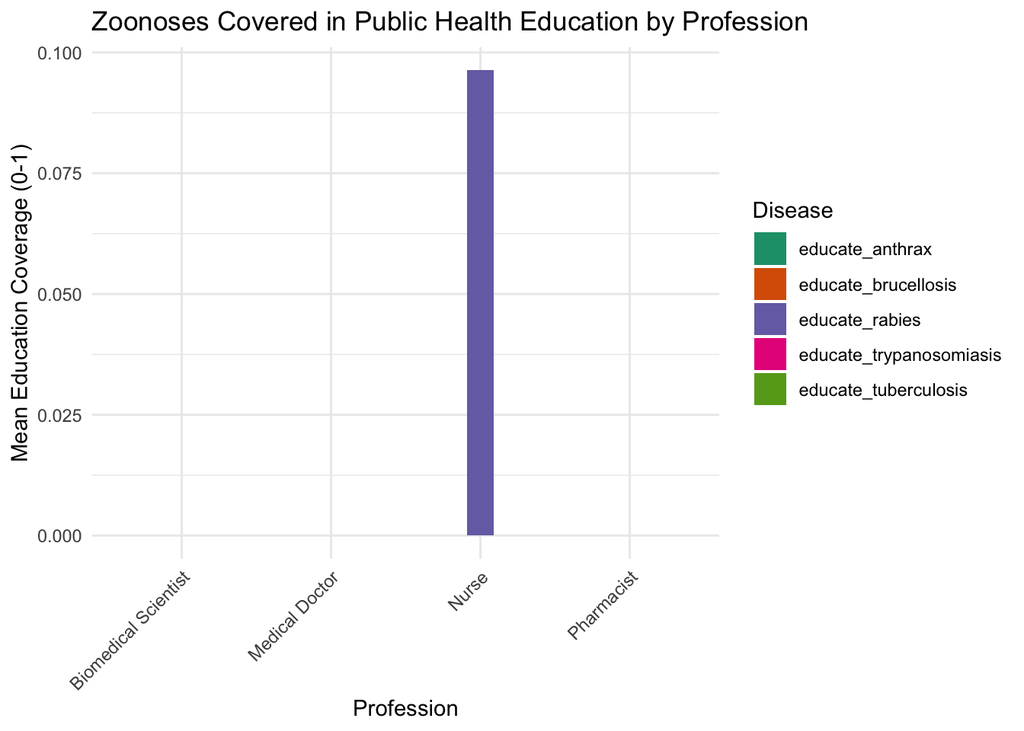

```
##
##
## # Education on anthrax
##
##
## Table: Test for educate_anthrax
##
## |                           |Test           | ChiSq| df| p.value|
## |:--------------------------|:--------------|-----:|--:|-------:|
## |Kruskal-Wallis chi-squared |Kruskal-Wallis |   NaN|  3|     NaN|
##
##
## # Education on rabies
##
##
## Table: Test for educate_rabies
##
## |                           |Test           | ChiSq| df| p.value|
## |:--------------------------|:--------------|-----:|--:|-------:|
## |Kruskal-Wallis chi-squared |Kruskal-Wallis |  1.78|  3|    0.62|
##
##
## # Education on brucellosis
##
##
## Table: Test for educate_brucellosis
##
## |                           |Test           | ChiSq| df| p.value|
## |:--------------------------|:--------------|-----:|--:|-------:|
## |Kruskal-Wallis chi-squared |Kruskal-Wallis |   NaN|  3|     NaN|
##
##
## # Education on trypanosomiasis
##
##
## Table: Test for educate_trypanosomiasis
##
## |                           |Test           | ChiSq| df| p.value|
## |:--------------------------|:--------------|-----:|--:|-------:|
## |Kruskal-Wallis chi-squared |Kruskal-Wallis |   NaN|  3|     NaN|
##
##
## # Education on tuberculosis
##
##
## Table: Test for educate_tuberculosis
##
## |                           |Test           | ChiSq| df| p.value|
## |:--------------------------|:--------------|-----:|--:|-------:|
## |Kruskal-Wallis chi-squared |Kruskal-Wallis |   NaN|  3|     NaN|
```

Profession vs Public Education on Rabies (Counts)

|  | No | Yes |
| --- | --- | --- |
| Biomedical Scientist | 8 | 0 |
| Medical Doctor | 4 | 0 |
| Nurse | 122 | 13 |
| Pharmacist | 5 | 0 |

```
##
##  Fisher's Exact Test for Count Data
##
## data:  table_test
## p-value = 1
## alternative hypothesis: two.sided
```

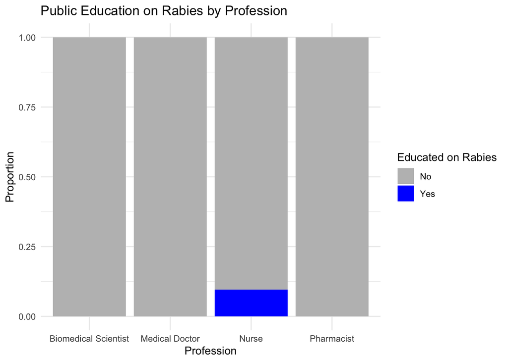

Profession vs Collaboration on Rabies (Counts)

|  | No | Yes |
| --- | --- | --- |
| Biomedical Scientist | 8 | 0 |
| Medical Doctor | 4 | 0 |
| Nurse | 126 | 9 |
| Pharmacist | 5 | 0 |

```
##
##  Fisher's Exact Test for Count Data
##
## data:  table_test
## p-value = 1
## alternative hypothesis: two.sided
```

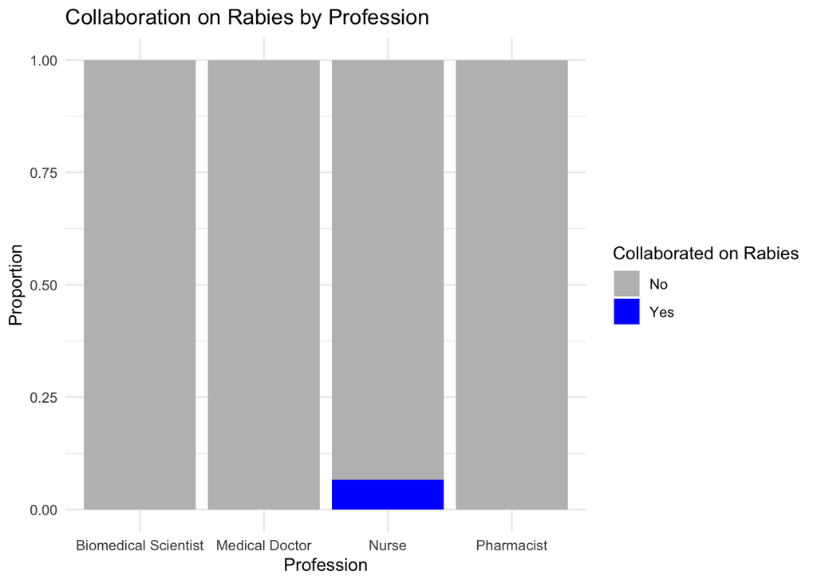

- Observations

Only educate_rabies has non-zero responses (13 Yes, mean = 0.096 for Nurses, 0 for others).

Others are all 0 (no education reported).

Visualization (Dodged Bar Plot): Only Nurses show non-zero mean education coverage (~0.096 for Rabies).

All other professions and diseases show zero coverage.

Plot highlights Nurses’ exclusive but low engagement in Rabies education.

Kruskal-Wallis Tests: educate_rabies: ChiSq = 1.78, df = 3, p = 0.62 (not significant).

Others (educate_anthrax, educate_brucellosis, educate_trypanosomiasis, educate_tuberculosis): NaN (no variation, all 0).

No significant differences, consistent with Fisher’s test for educate_rabies (p = 1.0).

Observation: Public education is limited to Rabies and Nurses (8.6% Yes).

No profession-based differences due to sparse data (13 Yes for Rabies, 0 for others).

# Conclusion

1. Knowledge of Zoonoses and One Health

General Zoonosis Knowledge :

Moderate knowledge (mean 1.53/3, 46.1% high).

No significant differences by profession (ANOVA p = 0.869, Fisher’s p = 0.965).

Medical Doctors and Biomedical Scientists have slightly higher medians, but small sample sizes (n=4, n=8) limit power.

Prioritized Zoonoses Knowledge: Strong knowledge (mean 6.53/9, 87.5% high).

No significant differences (ANOVA p = 0.246, Fisher’s p = 0.793).

Medical Doctors score highest (median ~8), but n=4.

Five Selected Zoonoses Knowledge:

Significant differences for brucellosis_knowledge_total (p = 0.0318) and trypanosomiasis_knowledge_total (p = 0.0107).

Rabies knowledge highest (mean 4.02/8), Brucellosis lowest (2.06/7).

Medical Doctors and Biomedical Scientists score higher for Brucellosis/Trypanosomiasis

Categorical tests infeasible due to invariant responses (all inadequate except Anthrax/Rabies).

One Health Knowledge:

Strong knowledge (mean 9.18/14, 78.9% high).

Significant for armed_conflict_one_health (p = 0.006), with Medical Doctors at 100% correct.

No significant differences overall (ANOVA p = 0.232, Fisher’s p = 0.357).

Medical Doctors (mean 12.50) and Pharmacists (100% high) excel, but n=4–5.

2. Experience with Zoonoses and One Health

General Experience:

Significant for zoonosis_training (p = 0.004), with Biomedical Scientists at 87.5% Yes

Other variables (zoonosis_workshop, zoonosis_collaboration, zoonotic_disease_encounter, zoonosis_public_education, one_health_training) not significant (p = 0.105–1.0).

Engagement low: workshops (7.2%), collaboration (5.9%), encounters (33.6%), public education (9.2%), One Health training (21.1%), zoonosis training (35.5%).

Zoonoses Controlled in Collaboration:

No significant differences for collab_rabies (Fisher’s p = 1.0, Kruskal-Wallis p = 0.754).

Rare (5.9% Yes), Nurse-only, all Rabies. Other diseases (Anthrax, Brucellosis, Trypanosomiasis, Tuberculosis) have zero collaboration.

Zoonoses Encountered :

Not significant for encounter_rabies (p = 0.277) or encounter_anthrax (p = 0.969); encounter_brucellosis is zero.

Rabies most encountered (28.3%), others rare (0.7–2.0%). Nurses dominate, Biomedical Scientists have some Rabies encounters (25%).

Zoonoses Covered in Public Health Education :

No significant differences for educate_rabies (Fisher’s p = 1.0, Kruskal-Wallis p = 0.62).

Rare (8.6% Yes), Nurse-only, Rabies-only. Other diseases (Anthrax, Brucellosis, Trypanosomiasis, Tuberculosis) have zero education.

3. Significant Findings

Knowledge:

brucellosis_knowledge_total: Medical Doctors and Biomedical Scientists > Nurses (p = 0.0318).

trypanosomiasis_knowledge_total: Medical Doctors and Biomedical Scientists > Nurses (p = 0.0107).

armed_conflict_one_health: Medical Doctors > Nurses (p = 0.006).

Experience:

zoonosis_training: Biomedical Scientists > Nurses (p = 0.004).

- Key trends

Knowledge Strengths: Prioritized zoonoses (87.5% high) and One Health (78.9% high) are strong, general zoonosis moderate (46.1% high). Rabies knowledge is highest, Brucellosis lowest.

Profession-Based Patterns: Medical Doctors: Highest knowledge scores (e.g., One Health mean 12.50, Brucellosis), perfect armed conflict knowledge, but low engagement (0–25% Yes) due to n=4.

Biomedical Scientists: Excel in training (87.5% zoonosis, 50% One Health), strong Brucellosis/Trypanosomiasis knowledge, some Rabies encounters (25%).

Nurses: Dominate encounters (34.1%), collaboration (6.7%), and education (9.6%) due to sample size (n=135), but moderate knowledge/training.

Pharmacists: Minimal involvement (0% Yes for most binary outcomes, 100% high One Health knowledge, but n=5).

Sparse Engagement: Collaboration, public education, and non-Rabies encounters are rare (0.7–9.2% Yes), mostly Nurse-driven.

Rabies Dominance: Most encountered (28.3%), collaborated (5.9%), and educated (8.6%) zoonosis.

- Visualizations

Stacked Bar Plots: Highlight Nurse-dominated, low “Yes” proportions for collaboration/education.

Boxplots: Show Medical Doctors’ high knowledge medians, Nurses’ wide spread.

Dodged Bar Plots: Confirm Nurses’ exclusive Rabies collaboration/education.

Heatmap: Visualizes Nurses’ dominance in Rabies encounters, sparse non-Rabies encounters.

- Limitations Profession Imbalance: Nurses (88.8%, 135/152) dominate, with small samples for Medical Doctors (4) and Pharmacists (5), reducing statistical power.

Sparse data

- Summary